# MarkS_Rating_StLouis_Starbucks_vs_Toronto_20200720

### 7/20/2020

### Using Foursquare API to determine Starbucks with the highest Customer Ratings in a large Metropolitan area

#### Finding the Starbucks stores with Highest Customer Ratings in St louis MO and then testing the same method

#### in Toronto, a city with much denser clusters of venues.

#### The Foursquare API has a limit to the number of search results and does not give the developer ratings

#### when there is a number of venues. I will work with their parameters to develop functions that perform multiple

#### searches capable of city-wide coverage.

#### Links to Content

Functions for Foursquare API requests

Foursquare Venues Search

Define Function for Recommendations with Intent parameter

Starbucks Recommendations Function

#### Searching for the Best Starbucks in St. Louis MO

Using getRecommendedIntent

Get All Starbucks St. Louis Locations

Get Starbucks with High Recomendations and Ratings

Map of Recommended Starbucks and highlighting those with better ratings

Get Venue Details with Ratings

St Louis Top 12 Starbucks

#### Toronto's Highest Rated Starbucks

Finding the Best Starbucks in Toronto

Missed High Ratings from Recommended_Coffee_Map

Data_Preparation_for_K-Means

Modified High Ratings Search for Toronto

Get Toronto Venue Details with Ratings

Map of Toronto's Best Starbucks

Which one is the Best Starbucks City?

```python
####  Tip for links:    [Link to the destination](#the_destination)  followed by   <a id='K-Means_Clustering'></a>
```

```python
import requests
# http requests & response used with Foursquare API

import json # library to handle JSON files
import pandas as pd
from pandas.io.json import json_normalize # tranform JSON file into a pandas dataframe
# Foursquare results will be in JSON and then flattened and stored in a Pandas Dataframe
```

```python
import numpy as np # library to handle data in a vectorized manner

#!conda install -c conda-forge geopy --yes # uncomment this line if you haven't completed the Foursquare API lab
from geopy.geocoders import Nominatim # convert an address into latitude and longitude values

# Geopy can calculate geodesic distance between two points using the geodesic distance or the great-circle distance,
# with a default of the geodesic distance available as the function geopy.distance.distance.
from geopy.distance import geodesic
from geopy.distance import great_circle

import scipy
from scipy.spatial import distance


# Matplotlib and associated plotting modules
%matplotlib inline
import matplotlib.pyplot as plt
import matplotlib.cm as cm
import matplotlib.colors as colors


# import k-means for clustering
from sklearn.cluster import KMeans

#!conda install -c conda-forge folium=0.5.0 --yes # uncomment this line if you haven't completed the Foursquare API lab
import folium # map rendering library

print('Libraries imported.')
```

```
Libraries imported.
```

```python
# folium should be version 0.11.0

print(folium.__version__)
```

```
0.11.0
```

```python
# Wide Display

from IPython.core.display import display, HTML
display(HTML("<style>.container { width:100% !important; }</style>"))
```

### Define Foursquare Credentials and Version

```python
CLIENT_ID = '1O1KN544PAGAVX5SIEEO4SINNIYJTELH1YMHPSOPLESWN1VF' # your Foursquare ID
CLIENT_SECRET = '3VB4HIYI1IYA0SYA5L3TLAJM0P4KFGOZ45FRMYMSGXCR4FTV' # your Foursquare Secret
VERSION = '20200514' # Foursquare API version

print('Your credentails:')
print('CLIENT_ID: ' + CLIENT_ID)
print('CLIENT_SECRET:' + CLIENT_SECRET)
```

```
Your credentails:
CLIENT_ID: 1O1KN544PAGAVX5SIEEO4SINNIYJTELH1YMHPSOPLESWN1VF
CLIENT_SECRET:3VB4HIYI1IYA0SYA5L3TLAJM0P4KFGOZ45FRMYMSGXCR4FTV
```

```python
# function that extracts the category of the venue
def get_categories(row):
    try:
        categories_list = row['categories']
    except:
        categories_list = row['venue.categories']

    if len(categories_list) == 0:
        return None
    else:
        return categories_list[0]['name']
```

### The Foursquare API is a RESTful API based on HTTP requests and JSON responses.

#### Create 3 functions that are able to run multiple API requests

### Foursquare /venues/search will produce all results that match query term and location.

#### Function to create Foursquare API Request

```python
def getVenuesSearch(query, latitudes, longitudes, radius = 15000, LIMIT = 50):


    search_results_all = pd.DataFrame(columns=['id','address', 'lat', 'lng'])
    i = 0

    for latitude, longitude in zip(latitudes, longitudes):
        print('centroid: ', i, latitude, longitude)

        # create the API request URL
        url = 'https://api.foursquare.com/v2/venues/search?&client_id={}&client_secret={}&v={}&ll={},{}&radius={}&limit={}&query={}'.format(
            CLIENT_ID,
            CLIENT_SECRET,
            VERSION,
            latitude,
            longitude,
            radius,
            LIMIT,
            query)
        print(url) # display URL


        # make the GET request
        results = requests.get(url).json()
        search_results = results['response']['venues']
        search_results_df = pd.json_normalize(search_results) # flatten JSON

        # filter columns
        filtered_columns = ['id', 'location.address', 'location.lat', 'location.lng']
        nearby_search_venues = search_results_df.loc[:, filtered_columns]

        # clean columns
        nearby_search_venues.columns = [col.split(".")[-1] for col in nearby_search_venues.columns]

        search_results_all = pd.concat([search_results_all, nearby_search_venues])
        print('search_results_all size: ', search_results_all.shape)
        i = i +1

    search_results_all = search_results_all.drop_duplicates(subset='id', ignore_index=True)
    print('search_results_all size: ', search_results_all.shape)

    return(search_results_all)
```

```python
# Calling getVenuesSearch function

# Run the above function
# Supply venue name query string - Example 'Starbucks'
# Supply numpy array of latitude & longitude values


# query = 'Starbucks'
# all_starbucks = getVenuesSearch(query, latitudes=coordinates[:, 0], longitudes=coordinates[:, 1])
```

### Foursquare Search/ Recommendations will find recommended venues for the latitude & longitude and intent

#### Function to create Foursquare API Request

```python
def getRecommendedIntent(intent, latitudes, longitudes, radius = 15000, LIMIT = 50):

    # Intent: One of: food, breakfast, brunch, lunch, coffee, dinner, dessert, drinks, shopping, fun, sights.
    # Specifies the top-level “intent” for a search.


    recommended_all = pd.DataFrame(columns=['id', 'name', 'categories', 'address', 'lat', 'lng'])
    i = 0

    for latitude, longitude in zip(latitudes, longitudes):
        print('centroid: ', i, latitude, longitude)

        # create the API request URL


        url = 'https://api.foursquare.com/v2/search/recommendations?&client_id={}&client_secret={}&v={}&ll={},{}&radius={}&intent={}&limit={}'.format(
            CLIENT_ID,
            CLIENT_SECRET,
            VERSION,
            latitude,
            longitude,
            radius,
            intent,
            LIMIT)
        print(url) # display URL


        # make the GET request
        results = requests.get(url).json()
        recommended = results['response']['group']['results']
        recommended_df = pd.json_normalize(recommended) # flatten JSON

        # filter columns
        filtered_columns = ['venue.id', 'venue.name', 'venue.categories', 'venue.location.address', 'venue.location.lat', 'venue.location.lng']
        recommended_venues = recommended_df.loc[:, filtered_columns]

        # filter the category for each row
        recommended_venues['venue.categories'] = recommended_venues.apply(get_categories, axis=1)

        # clean columns
        recommended_venues.columns = [col.split(".")[-1] for col in recommended_venues.columns]

        recommended_all = pd.concat([recommended_all, recommended_venues])
        print('recommended_all size: ', recommended_all.shape)
        i = i +1

    recommended_all = recommended_all.drop_duplicates(subset='id', ignore_index=True)
    print('recommended_all size: ', recommended_all.shape)

    return(recommended_all)
```

```python
# Run the above function
# Supply intent - One of: food, breakfast, brunch, lunch, coffee, dinner, dessert, drinks, shopping, fun, sights
# Supply numpy array of latitude & longitude values
# Uncomment the next line ...

# recommended_starbucks_clusters = getRecommendedIntent(intent, latitudes=centers[:, 0], longitudes=centers[:, 1])
```

### Foursquare Search/ Recommendations will find recommended venues for the latitude & longitude and matching name query.

#### Function to create Foursquare API Request

```python
def getRecommended(latitudes, longitudes, radius = 35000, query = 'Starbucks', LIMIT = 25):

    # 43.5 km = 27 miles, distance between farthest Starbucks with rating >= 8.0
    # 20 km = 12 miles;  35 km = 22 miles

    Starbucks_Rating = pd.DataFrame(columns=['id', 'name', 'categories', 'address', 'lat', 'lng'])
    recommended_all = pd.DataFrame(columns=['id', 'name', 'categories', 'address', 'lat', 'lng'])
    i = 0

    for latitude, longitude in zip(latitudes, longitudes):
        print('centroid: ', i, latitude, longitude)

        # create the API request URL

        url = 'https://api.foursquare.com/v2/search/recommendations?&client_id={}&client_secret={}&v={}&ll={},{}&radius={}&query={}&limit={}'.format(
            CLIENT_ID,
            CLIENT_SECRET,
            VERSION,
            latitude,
            longitude,
            radius,
            query,
            LIMIT)
        print(url) # display URL


        # make the GET request
        results = requests.get(url).json()
        recommended = results['response']['group']['results']
        recommended_df = pd.json_normalize(recommended) # flatten JSON

        # filter columns
        filtered_columns = ['venue.id', 'venue.name', 'venue.categories', 'venue.location.address', 'venue.location.lat', 'venue.location.lng']
        recommended_venues = recommended_df.loc[:, filtered_columns]

        # filter the category for each row
        recommended_venues['venue.categories'] = recommended_venues.apply(get_categories, axis=1)

        # clean columns
        recommended_venues.columns = [col.split(".")[-1] for col in recommended_venues.columns]
        recommended_all = pd.concat([recommended_all, recommended_venues])

        print('recommended_all size: ', recommended_all.shape)
        i = i +1

    Starbucks_Rating = recommended_all[recommended_all.duplicated(subset='id')]
    # Keep row if duplicated, meaning recommended Starbucks appears even though it may be farther away, so high rating
    Starbucks_Rating = Starbucks_Rating.drop_duplicates(subset='id', ignore_index=True)
    # Now remove any duplicates

    recommended_all = recommended_all.drop_duplicates(subset='id', ignore_index=True)

    print('Starbucks_Rating size: ', Starbucks_Rating.shape)
    print('recommended_all size: ', recommended_all.shape)

    return(Starbucks_Rating, recommended_all)
```

```python
# Run the above function

# starbucks_rating, recommended_starbucks = getRecommended(latitudes=centers[:, 0], longitudes=centers[:, 1])
```

### Coordinates to use for 4 Regions around St Louis MO.

```python
#### While Search/ Recommendations isn't time of day sensitive as is Venues/ Explore, it is very sensitive to your location.
#### The results list will begin with the top venues close to you & high ratings, followed by recommended venues that are still close but lower ratings,
#### and then top rated sites that may be at the edge of your search radius.

### St. Louis spans approximately 23 miles North-South & 25 miles East-West with a population of 2 million and greater metropolitan area population of 2.8 million.

#### Toronto covers an area of 630 square kilometres (243 sq mi), population of 3 million and the greater Toronto area population of 6 million.
#### with a maximum north–south distance of 21 kilometres (13 mi)
#### and a maximum east–west distance of 43 km (27 mi). It has a 46-kilometre (29 mi) long waterfront shoreline, on the northwestern shore of Lake Ontario.
```

```python
# The Hill
# St. Louis, MO
# 38.615205, -90.272254
# latitude = 38.615205
# longitude = -90.272254


# 7333 S Lindbergh Blvd
# St. Louis, MO 63125
# 38.506835, -90.326528


# Hollywood Casino Amphitheatre - St. Louis, 14141 Riverport Dr, Maryland Heights, MO 63043
# 25 miles from Gateway Arch ( 40 km )  Current Max search Radius is 100 km

# Maryland Heights
# Missouri 63043
# 38.744059, -90.469580


# St Charles, MO 63301
# 38.776249, -90.483434

# Chesterfield
# Missouri 63005
# 38.668963, -90.598782
```

```python
# Coordinates to use for 4 Regions around St Louis with 15 km search radius each,

#  38.615205, -90.272254  The Hill
# 38.776249, -90.483434    St Charles
#  38.668963, -90.598782   Chesterfield
# 38.506835, -90.326528  South County

coordinates = np.array([38.615205, -90.272254, 38.776249, -90.483434, 38.668963, -90.598782 , 38.506835, -90.326528  ]).reshape(4, 2)
coordinates
```

```
array([[ 38.615205, -90.272254],
       [ 38.776249, -90.483434],
       [ 38.668963, -90.598782],
       [ 38.506835, -90.326528]])
```

### getRecommendedIntent function call

```python
# getRecommendedIntent function

# Run the above function
# Supply intent - One of: food, breakfast, brunch, lunch, coffee, dinner, dessert, drinks, shopping, fun, sights
# Supply numpy array of latitude & longitude values
# Uncomment the next line ...

intent = 'coffee'
recommended_coffee_StL = getRecommendedIntent(intent, latitudes=coordinates[:, 0], longitudes=coordinates[:, 1])
```

```
centroid:  0 38.615205 -90.272254
https://api.foursquare.com/v2/search/recommendations?&client_id=1O1KN544PAGAVX5SIEEO4SINNIYJTELH1YMHPSOPLESWN1VF&client_secret=3VB4HIYI1IYA0SYA5L3TLAJM0P4KFGOZ45FRMYMSGXCR4FTV&v=20200514&ll=38.615205,-90.272254&radius=15000&intent=coffee&limit=50
recommended_all size:  (50, 6)
centroid:  1 38.776249 -90.483434
https://api.foursquare.com/v2/search/recommendations?&client_id=1O1KN544PAGAVX5SIEEO4SINNIYJTELH1YMHPSOPLESWN1VF&client_secret=3VB4HIYI1IYA0SYA5L3TLAJM0P4KFGOZ45FRMYMSGXCR4FTV&v=20200514&ll=38.776249,-90.483434&radius=15000&intent=coffee&limit=50
recommended_all size:  (100, 6)
centroid:  2 38.668963 -90.598782
https://api.foursquare.com/v2/search/recommendations?&client_id=1O1KN544PAGAVX5SIEEO4SINNIYJTELH1YMHPSOPLESWN1VF&client_secret=3VB4HIYI1IYA0SYA5L3TLAJM0P4KFGOZ45FRMYMSGXCR4FTV&v=20200514&ll=38.668963,-90.598782&radius=15000&intent=coffee&limit=50
recommended_all size:  (150, 6)
centroid:  3 38.506835 -90.326528
https://api.foursquare.com/v2/search/recommendations?&client_id=1O1KN544PAGAVX5SIEEO4SINNIYJTELH1YMHPSOPLESWN1VF&client_secret=3VB4HIYI1IYA0SYA5L3TLAJM0P4KFGOZ45FRMYMSGXCR4FTV&v=20200514&ll=38.506835,-90.326528&radius=15000&intent=coffee&limit=50
recommended_all size:  (200, 6)
recommended_all size:  (153, 6)
```

```python
recommended_coffee_StL.head(20)
```

|  | id | name | categories | address | lat | lng |
| --- | --- | --- | --- | --- | --- | --- |
| 0 | 528d4d9a498e2afb49371f35 | Park Avenue Coffee | Coffee Shop | 5105 Columbia Ave | 38.610811 | -90.272584 |
| 1 | 4b53639af964a520539a27e3 | World's Fair Donuts | Donut Shop | 1904 S Vandeventer Ave | 38.616782 | -90.261832 |
| 2 | 59fddb1cee712077f2be7035 | Fiddlehead Fern Cafe | Café | NaN | 38.614390 | -90.250742 |
| 3 | 523db9ae11d26840aed119ac | Rise Coffeehouse | Coffee Shop | 4180 Manchester Ave | 38.627378 | -90.253390 |
| 4 | 5148a464e4b06d5da8c492c6 | Russell's on Macklind | Café | 5400 Murdoch Ave | 38.586823 | -90.284382 |
| 5 | 4acbc3faf964a520dac520e3 | SweetArt | Café | 2203 S 39th St | 38.611688 | -90.245939 |
| 6 | 4adbfa8bf964a520372b21e3 | The London Tea Room | Tea Room | 3128 Morganford Rd | 38.603617 | -90.261169 |
| 7 | 502ea937d63ec9ac23368b4a | Comet Coffee | Coffee Shop | 5708 Oakland Ave | 38.630144 | -90.281997 |
| 8 | 55a51b9a498e2b2b986ac5c2 | Starbucks | Coffee Shop | 2350 South Grand Ave | 38.608347 | -90.240794 |
| 9 | 4ae473a3f964a520a99a21e3 | Hartford Coffee Company | Coffee Shop | 3974 Hartford St | 38.602613 | -90.252517 |
| 10 | 542031bf498e7ac7044b33a5 | Kitchen House Coffee | Coffee Shop | 3149 Shenandoah Ave | 38.609067 | -90.233717 |
| 11 | 4ad9f235f964a5202a1c21e3 | Shaw's Coffee | Coffee Shop | 5147 Shaw Ave | 38.618005 | -90.272383 |
| 12 | 4afc3c9bf964a520c32022e3 | The Crave Coffee House | Coffee Shop | 3500 Caroline St | 38.621967 | -90.235257 |
| 13 | 518691bf498ef45e67b24a80 | Cafe Flora | Café | 4344 Shaw Blvd. (inside Missouri Botanical Gar... | 38.613924 | -90.257314 |
| 14 | 4acbc3faf964a520f9c520e3 | Kaldi’s Coffee House | Coffee Shop | 700 DE Mun Ave | 38.638702 | -90.307715 |
| 15 | 4afabad8f964a5206d1822e3 | Donut Drive-In | Donut Shop | 6525 Chippewa St | 38.592158 | -90.302796 |
| 16 | 4ad8c938f964a5209f1421e3 | Northwest Coffee Roasting Company | Coffee Shop | 4251 Laclede Ave | 38.638428 | -90.250794 |
| 17 | 4c8bf8e25e048cfa3892c8cd | Cafe Nova | Café | 5611 S Kingshighway Blvd | 38.579301 | -90.281502 |
| 18 | 4ae49b3cf964a520429c21e3 | Starbucks | Coffee Shop | 4656 Maryland Ave | 38.644480 | -90.261246 |
| 19 | 4ada6d30f964a5207f2221e3 | Gelateria Del Leone | Coffee Shop | 3197 S Grand Blvd | 38.599378 | -90.242850 |

```python
recommended_coffee_StL.shape
```

```
(153, 6)
```

```python
recommended_coffee_StL.columns
```

```
Index(['id', 'name', 'categories', 'address', 'lat', 'lng'], dtype='object')
```

```python
# df[df['A'].str.contains("hello")]

recommended_coffee_StL[recommended_coffee_StL['name'].str.contains("Starbucks")]
```

|  | id | name | categories | address | lat | lng |
| --- | --- | --- | --- | --- | --- | --- |
| 8 | 55a51b9a498e2b2b986ac5c2 | Starbucks | Coffee Shop | 2350 South Grand Ave | 38.608347 | -90.240794 |
| 18 | 4ae49b3cf964a520429c21e3 | Starbucks | Coffee Shop | 4656 Maryland Ave | 38.644480 | -90.261246 |
| 24 | 4afeb7c4f964a5200a3022e3 | Starbucks | Coffee Shop | 3700 S Kingshighway Blvd | 38.592558 | -90.272176 |
| 45 | 59a0188161f0701bf02c6aec | Starbucks | Coffee Shop | 212 S Grand Blvd | 38.632654 | -90.233880 |
| 54 | 4adf0db3f964a5204a7721e3 | Starbucks | Coffee Shop | 1030 S 5th St | 38.773824 | -90.490665 |
| 63 | 5921dfd365cdf831bcbaa96a | Starbucks | Coffee Shop | 995 Northwest Plaza | 38.736420 | -90.398333 |
| 70 | 4dea85b652b11677f03e362b | Starbucks | Coffee Shop | 12275 Saint Charles Rock Rd | 38.753544 | -90.426060 |
| 71 | 4af0cf7cf964a5205adf21e3 | Starbucks | Coffee Shop | 111 W Port Plz Bldg | 38.701365 | -90.446090 |
| 75 | 5a3898e8a92d98694010220d | Starbucks | Coffee Shop | 995 NW Plaza Drive | 38.736298 | -90.397568 |
| 78 | 5d2d121652fae70023a9ccd4 | Starbucks | Coffee Shop | Gate E29 (at Lambert-St. Louis International A... | 38.737803 | -90.356627 |
| 87 | 4cbf5e737dc9a093116138f5 | Starbucks | Coffee Shop | 320 Mid Rivers Ctr | 38.794433 | -90.622285 |
| 95 | 4f326c7319836c91c7d66a72 | Starbucks | Coffee Shop | 3788 Elm St | 38.821423 | -90.515533 |
| 96 | 510ac71fe4b0b2202ff3b9e7 | Starbucks Gate C19 | Coffee Shop | NaN | 38.742151 | -90.362074 |
| 101 | 4aee1eb0f964a52045d221e3 | Starbucks | Coffee Shop | 17293 Chesterfield Airport Rd | 38.668913 | -90.598840 |
| 106 | 52869068498e3289da674622 | Starbucks | Coffee Shop | 40 Thf Blvd | 38.667496 | -90.585280 |
| 107 | 4ae8bf79f964a520eeb121e3 | Starbucks | Coffee Shop | 1720 Clarkson Rd | 38.642254 | -90.566186 |
| 109 | 5a142b5f6e46500c14544b7b | Starbucks | Coffee Shop | 1024B Town and Country Crossing Dr | 38.621975 | -90.519123 |
| 113 | 4da8db1cfa8cc764970ab520 | Starbucks | Coffee Shop | 125 plaza dr | 38.582077 | -90.628166 |
| 134 | 5362b1ef498ecbc46d106438 | Starbucks | Coffee Shop | 7333 Lindbergh | 38.506776 | -90.326607 |
| 136 | 4af45b95f964a520a5f121e3 | Starbucks | Coffee Shop | 12460 Tesson Ferry Rd | 38.508217 | -90.375396 |
| 138 | 529cdedc11d27ffeb9efd34e | Starbucks | Coffee Shop | 4250 Rusty Rd | 38.508043 | -90.338967 |
| 139 | 4b2426f1f964a5204a6224e3 | Starbucks | Coffee Shop | 53K S County Center Way | 38.506681 | -90.331441 |

```python
len(recommended_coffee_StL[recommended_coffee_StL['name'].str.contains("Starbucks")])
```

```
22
```

```python
len(recommended_coffee_StL)
```

```
153
```

```python
len(recommended_coffee_StL[recommended_coffee_StL['name'].str.contains("Starbucks")]) / len(recommended_coffee_StL)
```

```
0.1437908496732026
```

### 14% of Foursquare Recommended Coffee Venues are Starbucks

```python
recommended_star = recommended_coffee_StL[recommended_coffee_StL['name'].str.contains("Starbucks")]
recommended_star.head()
```

|  | id | name | categories | address | lat | lng |
| --- | --- | --- | --- | --- | --- | --- |
| 8 | 55a51b9a498e2b2b986ac5c2 | Starbucks | Coffee Shop | 2350 South Grand Ave | 38.608347 | -90.240794 |
| 18 | 4ae49b3cf964a520429c21e3 | Starbucks | Coffee Shop | 4656 Maryland Ave | 38.644480 | -90.261246 |
| 24 | 4afeb7c4f964a5200a3022e3 | Starbucks | Coffee Shop | 3700 S Kingshighway Blvd | 38.592558 | -90.272176 |
| 45 | 59a0188161f0701bf02c6aec | Starbucks | Coffee Shop | 212 S Grand Blvd | 38.632654 | -90.233880 |
| 54 | 4adf0db3f964a5204a7721e3 | Starbucks | Coffee Shop | 1030 S 5th St | 38.773824 | -90.490665 |

```python
#Recommended_Coffee_Map
```

### Map of Recommended Coffee Locations

```python
# The Hill
# St. Louis, MO
# 38.615205, -90.272254


near = 'St Louis, MO'

latitude = 38.615205
longitude = -90.272254
```

```python
#  Recommendation Map showing results of 4 regions

map = folium.Map(location=[latitude, longitude], zoom_start=11, control_scale=True)

#  parse_html=True
# I can add markers on the map with popup for Postal Code but borough name will not work reliably with variety of
# characters, such as / . ''. Use folium.Popup with parse_html

for i in range(0,len(recommended_coffee_StL)):
    folium.Marker([recommended_coffee_StL.iloc[i]['lat'], recommended_coffee_StL.iloc[i]['lng']],
                  popup=folium.Popup(recommended_coffee_StL.iloc[i]['name'], parse_html=True),
                  icon=folium.Icon(color='darkblue', icon='info-sign')
                  ).add_to(map)


for i in range(0,len(recommended_star)):
    folium.Marker([recommended_star.iloc[i]['lat'], recommended_star.iloc[i]['lng']],
                  popup=folium.Popup(recommended_star.iloc[i]['name'], parse_html=True),
                  icon=folium.Icon(color='green', icon='info-sign')
                  ).add_to(map)


map.save('map_Recommended_Coffee_StLouis_4lat_lng_20200722.html')

map
```

[interactive chart not shown]

### Recommended Coffee Venues around St Louis, MO. Starbucks are in Green. Click on info sign to see Venue name

### Find All Starbucks around St Louis MO

```python
# Coordinates to use for 4 Regions around St Louis with 15 km search radius each,

#  38.615205, -90.272254  The Hill
# 38.776249, -90.483434    St Charles
#  38.668963, -90.598782   Chesterfield
# 38.506835, -90.326528  South County

coordinates = np.array([38.615205, -90.272254, 38.776249, -90.483434, 38.668963, -90.598782 , 38.506835, -90.326528  ]).reshape(4, 2)
coordinates
```

```
array([[ 38.615205, -90.272254],
       [ 38.776249, -90.483434],
       [ 38.668963, -90.598782],
       [ 38.506835, -90.326528]])
```

```python
# getVenuesSearch
# Calling getVenuesSearch function

# Run the above function
# Supply venue name query string - Example 'Starbucks'
# Supply numpy array of latitude & longitude values


query = 'Starbucks'
all_starbucks = getVenuesSearch(query, latitudes=coordinates[:, 0], longitudes=coordinates[:, 1])
```

```
centroid:  0 38.615205 -90.272254
https://api.foursquare.com/v2/venues/search?&client_id=1O1KN544PAGAVX5SIEEO4SINNIYJTELH1YMHPSOPLESWN1VF&client_secret=3VB4HIYI1IYA0SYA5L3TLAJM0P4KFGOZ45FRMYMSGXCR4FTV&v=20200514&ll=38.615205,-90.272254&radius=15000&limit=50&query=Starbucks
search_results_all size:  (50, 4)
centroid:  1 38.776249 -90.483434
https://api.foursquare.com/v2/venues/search?&client_id=1O1KN544PAGAVX5SIEEO4SINNIYJTELH1YMHPSOPLESWN1VF&client_secret=3VB4HIYI1IYA0SYA5L3TLAJM0P4KFGOZ45FRMYMSGXCR4FTV&v=20200514&ll=38.776249,-90.483434&radius=15000&limit=50&query=Starbucks
search_results_all size:  (95, 4)
centroid:  2 38.668963 -90.598782
https://api.foursquare.com/v2/venues/search?&client_id=1O1KN544PAGAVX5SIEEO4SINNIYJTELH1YMHPSOPLESWN1VF&client_secret=3VB4HIYI1IYA0SYA5L3TLAJM0P4KFGOZ45FRMYMSGXCR4FTV&v=20200514&ll=38.668963,-90.598782&radius=15000&limit=50&query=Starbucks
search_results_all size:  (132, 4)
centroid:  3 38.506835 -90.326528
https://api.foursquare.com/v2/venues/search?&client_id=1O1KN544PAGAVX5SIEEO4SINNIYJTELH1YMHPSOPLESWN1VF&client_secret=3VB4HIYI1IYA0SYA5L3TLAJM0P4KFGOZ45FRMYMSGXCR4FTV&v=20200514&ll=38.506835,-90.326528&radius=15000&limit=50&query=Starbucks
search_results_all size:  (177, 4)
search_results_all size:  (111, 4)
```

#### There are a total of 111 Starbucks Stores in the St. Louis area.

```python
all_starbucks
```

|  | id | address | lat | lng |
| --- | --- | --- | --- | --- |
| 0 | 4afeb7c4f964a5200a3022e3 | 3700 S Kingshighway Blvd | 38.592558 | -90.272176 |
| 1 | 4af9f1a7f964a520771522e3 | 1042 Loughborough Ave Ste A | 38.557545 | -90.262024 |
| 2 | 4ade0d15f964a520ad6a21e3 | 6621 Delmar Blvd | 38.656211 | -90.306120 |
| 3 | 4ae49b3cf964a520429c21e3 | 4656 Maryland Ave | 38.644480 | -90.261246 |
| 4 | 4afd6d11f964a520bd2722e3 | 6622 Chippewa St | 38.590708 | -90.305082 |
| ... | ... | ... | ... | ... |
| 106 | 4f32218319836c91c7b91d40 | 6070 Telegraph Rd | 38.456341 | -90.305351 |
| 107 | 4f1ad46be4b0918979127d86 | 3884 State Route 141 | 38.444690 | -90.374603 |
| 108 | 5244657811d277f9c220aeec | 3849 Vogel Rd | 38.414097 | -90.395460 |
| 109 | 5773d965498e1f69ad899167 | 10779 Watson Rd | 38.555390 | -90.411002 |
| 110 | 4b76febbf964a52099722ee3 | 721 Gravois Rd | 38.512226 | -90.447359 |

111 rows × 4 columns

```python
all_starbucks.columns
```

```
Index(['id', 'address', 'lat', 'lng'], dtype='object')
```

```python
# Save all_starbucks for offline review
# df.to_pickle('file_name')  # where to save it, usually as a .pkl

all_starbucks.to_pickle('StL_All_Starbucks_20200722.pkl')
```

```python
# The Hill
# St. Louis, MO
# 38.615205, -90.272254

latitude = 38.615205
longitude = -90.272254
```

```python
#  All Starbucks Map showing results of 4 regions

map = folium.Map(location=[latitude, longitude], zoom_start=12, control_scale=True)

#  parse_html=True
# I can add markers on the map with popup for Postal Code but borough name will not work reliably with variety of
# characters, such as / . ''. Use folium.Popup with parse_html

for i in range(0,len(all_starbucks)):
    folium.Marker([all_starbucks.iloc[i]['lat'], all_starbucks.iloc[i]['lng']],
                  popup=folium.Popup(all_starbucks.iloc[i]['address'], parse_html=True),
                  icon=folium.Icon(color='green', icon='info-sign')
                  ).add_to(map)


map.save('map_all_starbucks_StLouis_4lat_lng_20200722.html')

map
```

[interactive chart not shown]

### 111 Starbucks locations around St. Louis

### Using Foursquare Recommendations to stay within budget for Premium Venue Detail Searches

```python
# Coordinates to use for 4 Regions around St Louis with 43.5 km search radius each,

#  38.615205, -90.272254  The Hill
# 38.776249, -90.483434    St Charles
#  38.668963, -90.598782   Chesterfield - remove
# 38.592419, -90.542934    14900 Manchester Rd, Ballwin
# 38.506835, -90.326528  South County

# NOTE: Tried with 2 & 3 search coordinates but missed a few high rated stores.

coordinates = np.array([38.615205, -90.272254, 38.776249, -90.483434, 38.592419, -90.542934, 38.506835, -90.326528  ]).reshape(4, 2)
coordinates
```

```
array([[ 38.615205, -90.272254],
       [ 38.776249, -90.483434],
       [ 38.592419, -90.542934],
       [ 38.506835, -90.326528]])
```

```python
# Run the function defined above.

# radius is left large but results LIMIT set small, 20 to allow highly recommended stores at a distance from lat lng to appear in multiple results.

# recommended_starbucks = getRecommended(latitudes=coordinates[:, 0], longitudes=coordinates[:, 1])
# getRecommended(latitudes, longitudes, radius = 35000, query = 'Starbucks', LIMIT = 25)

# 18.6 miles = 30 km

# getRecommended returns 2 dataframes. The recommended_starbucks df is all recommended stores from 4 different search locations with duplicates removed.

# The starbucks_rating df will KEEP only rows that are duplicated, meaning recommended Starbucks appearing farther away, at edges of one search radius, so
# appearing lower in results list, will appear higher in results when the search is repeated at coordinates that are closer to it. A store that only
# made it on one recommended list, made it because it was very close to the search coordinates.
# After single entries are removed, we are left with a list of the most highly rated stores, but may also have 2 or 3 entries due to 4 searches.
# The last step is to remove the duplicates of these top rated stores.

starbucks_rating, recommended_starbucks = getRecommended(latitudes=coordinates[:, 0], longitudes=coordinates[:, 1])
```

```
centroid:  0 38.615205 -90.272254
https://api.foursquare.com/v2/search/recommendations?&client_id=1O1KN544PAGAVX5SIEEO4SINNIYJTELH1YMHPSOPLESWN1VF&client_secret=3VB4HIYI1IYA0SYA5L3TLAJM0P4KFGOZ45FRMYMSGXCR4FTV&v=20200514&ll=38.615205,-90.272254&radius=35000&query=Starbucks&limit=25
recommended_all size:  (25, 6)
centroid:  1 38.776249 -90.483434
https://api.foursquare.com/v2/search/recommendations?&client_id=1O1KN544PAGAVX5SIEEO4SINNIYJTELH1YMHPSOPLESWN1VF&client_secret=3VB4HIYI1IYA0SYA5L3TLAJM0P4KFGOZ45FRMYMSGXCR4FTV&v=20200514&ll=38.776249,-90.483434&radius=35000&query=Starbucks&limit=25
recommended_all size:  (50, 6)
centroid:  2 38.592419 -90.542934
https://api.foursquare.com/v2/search/recommendations?&client_id=1O1KN544PAGAVX5SIEEO4SINNIYJTELH1YMHPSOPLESWN1VF&client_secret=3VB4HIYI1IYA0SYA5L3TLAJM0P4KFGOZ45FRMYMSGXCR4FTV&v=20200514&ll=38.592419,-90.542934&radius=35000&query=Starbucks&limit=25
recommended_all size:  (75, 6)
centroid:  3 38.506835 -90.326528
https://api.foursquare.com/v2/search/recommendations?&client_id=1O1KN544PAGAVX5SIEEO4SINNIYJTELH1YMHPSOPLESWN1VF&client_secret=3VB4HIYI1IYA0SYA5L3TLAJM0P4KFGOZ45FRMYMSGXCR4FTV&v=20200514&ll=38.506835,-90.326528&radius=35000&query=Starbucks&limit=25
recommended_all size:  (100, 6)
Starbucks_Rating size:  (28, 6)
recommended_all size:  (43, 6)
```

```python
starbucks_rating
```

|  | id | name | categories | address | lat | lng |
| --- | --- | --- | --- | --- | --- | --- |
| 0 | 584ff98a0aac75044472aaad | Starbucks | Coffee Shop | 11538 Page Service Dr | 38.699668 | -90.421316 |
| 1 | 4bb79a3cb35776b041dbc701 | Starbucks | Coffee Shop | 11464 Olive Blvd | 38.671368 | -90.435840 |
| 2 | 54bc2971498e3e13bd3946b5 | Starbucks | Coffee Shop | 7036 Clayton Ave | 38.633045 | -90.306122 |
| 3 | 4ae632a9f964a52084a521e3 | Starbucks | Coffee Shop | 1500 S Lindbergh Blvd | 38.632549 | -90.404777 |
| 4 | 4be1809b8e2962b520589b0a | Starbucks | Coffee Shop | 9616 Manchester Road | 38.608397 | -90.367306 |
| 5 | 4af82696f964a520290b22e3 | Starbucks | Coffee Shop | 343 S Kirkwood Rd | 38.577435 | -90.406850 |
| 6 | 4b566e45f964a520151028e3 | Starbucks | Coffee Shop | 922 South Meramec Station Rd., | 38.536537 | -90.496540 |
| 7 | 4ae49b3cf964a520429c21e3 | Starbucks | Coffee Shop | 4656 Maryland Ave | 38.644480 | -90.261246 |
| 8 | 4b313eb2f964a5200e0325e3 | Starbucks | Coffee Shop | 80 W County Ctr | 38.599907 | -90.447300 |
| 9 | 4adb70f4f964a520822721e3 | Starbucks | Coffee Shop | 2300 S Brentwood Blvd | 38.619538 | -90.348211 |
| 10 | 4af207d0f964a52052e521e3 | Starbucks | Coffee Shop | 2 N Central Ave | 38.650432 | -90.338015 |
| 11 | 4af713c1f964a5208d0522e3 | Starbucks | Coffee Shop | 9590 Watson Rd | 38.556990 | -90.381181 |
| 12 | 4adb6c88f964a5204f2721e3 | Starbucks | Coffee Shop | 14900 Manchester Rd | 38.592656 | -90.543162 |
| 13 | 4af2ca77f964a52084e821e3 | Starbucks | Coffee Shop | 14128 Manchester Rd | 38.593239 | -90.497492 |
| 14 | 4ae05ce0f964a520d57e21e3 | Starbucks | Coffee Shop | 13448 Clayton Rd | 38.626513 | -90.481608 |
| 15 | 4ae9809ef964a520f2b421e3 | Starbucks | Coffee Shop | 699 Gravois Bluffs Blvd | 38.507950 | -90.442790 |
| 16 | 4aee1eb0f964a52045d221e3 | Starbucks | Coffee Shop | 17293 Chesterfield Airport Rd | 38.668913 | -90.598840 |
| 17 | 5362b1ef498ecbc46d106438 | Starbucks | Coffee Shop | 7333 Lindbergh | 38.506776 | -90.326607 |
| 18 | 4af45b95f964a520a5f121e3 | Starbucks | Coffee Shop | 12460 Tesson Ferry Rd | 38.508217 | -90.375396 |
| 19 | 55e1c55b498e967647b98c27 | Starbucks | Coffee Shop | 10015 Gravois Road | 38.551113 | -90.333694 |
| 20 | 4b2d109ef964a52076cd24e3 | Starbucks | Coffee Shop | 6187 Mid Rivers Mall Dr | 38.742573 | -90.634930 |
| 21 | 4adf0db3f964a5204a7721e3 | Starbucks | Coffee Shop | 1030 S 5th St | 38.773824 | -90.490665 |
| 22 | 4b3a3b5ff964a520a96225e3 | Starbucks | Coffee Shop | 4581 Highway K | 38.719202 | -90.702113 |
| 23 | 55a51b9a498e2b2b986ac5c2 | Starbucks | Coffee Shop | 2350 South Grand Ave | 38.608347 | -90.240794 |
| 24 | 4af9f1a7f964a520771522e3 | Starbucks | Coffee Shop | 1042 Loughborough Ave Ste A | 38.557545 | -90.262024 |
| 25 | 4afeb7c4f964a5200a3022e3 | Starbucks | Coffee Shop | 3700 S Kingshighway Blvd | 38.592558 | -90.272176 |
| 26 | 4afd6d11f964a520bd2722e3 | Starbucks | Coffee Shop | 6622 Chippewa St | 38.590708 | -90.305082 |
| 27 | 4af9e6fdf964a520211522e3 | Starbucks | Coffee Shop | 1 S Old Orchard Ave | 38.590803 | -90.339254 |

```python
# df.to_pickle('file_name')  # where to save it, usually as a .pkl

starbucks_rating.to_pickle('StL_Starbucks_Top28_20200722.pkl')
```

```python
recommended_starbucks.shape
```

```
(43, 6)
```

```python
# map of recommended Starbucks
```

```python
#  Recommended Starbucks Map showing results of 4 regions

# The Hill
# St. Louis, MO
# 38.615205, -90.272254

latitude = 38.615205
longitude = -90.272254

map = folium.Map(location=[latitude, longitude], zoom_start=12, control_scale=True)

#  parse_html=True
# I can add markers on the map with popup for Postal Code but borough name will not work reliably with variety of
# characters, such as / . ''. Use folium.Popup with parse_html

for i in range(0,len(recommended_starbucks)):
    folium.Marker([recommended_starbucks.iloc[i]['lat'], recommended_starbucks.iloc[i]['lng']],
                  popup=folium.Popup(recommended_starbucks.iloc[i]['address'], parse_html=True),
                  icon=folium.Icon(color='green', icon='info-sign')
                  ).add_to(map)


for i in range(0,len(starbucks_rating)):
    folium.Marker([starbucks_rating.iloc[i]['lat'], starbucks_rating.iloc[i]['lng']],
                  popup=folium.Popup(starbucks_rating.iloc[i]['address'], parse_html=True),
                  icon=folium.Icon(color='purple', icon='info-sign')
                  ).add_to(map)


map.save('map_recommended_rated_starbucks_StLouis_4lat_lng_20200722.html')

map
```

[interactive chart not shown]

### Recommended Starbucks are in Green, 28 stores with the Highest ratings are in purple.

```python
len(starbucks_rating)
```

```
28
```

```python
starbucks_rating.id.iloc[0:28]
```

```
0     584ff98a0aac75044472aaad
1     4bb79a3cb35776b041dbc701
2     54bc2971498e3e13bd3946b5
3     4ae632a9f964a52084a521e3
4     4be1809b8e2962b520589b0a
5     4af82696f964a520290b22e3
6     4b566e45f964a520151028e3
7     4ae49b3cf964a520429c21e3
8     4b313eb2f964a5200e0325e3
9     4adb70f4f964a520822721e3
10    4af207d0f964a52052e521e3
11    4af713c1f964a5208d0522e3
12    4adb6c88f964a5204f2721e3
13    4af2ca77f964a52084e821e3
14    4ae05ce0f964a520d57e21e3
15    4ae9809ef964a520f2b421e3
16    4aee1eb0f964a52045d221e3
17    5362b1ef498ecbc46d106438
18    4af45b95f964a520a5f121e3
19    55e1c55b498e967647b98c27
20    4b2d109ef964a52076cd24e3
21    4adf0db3f964a5204a7721e3
22    4b3a3b5ff964a520a96225e3
23    55a51b9a498e2b2b986ac5c2
24    4af9f1a7f964a520771522e3
25    4afeb7c4f964a5200a3022e3
26    4afd6d11f964a520bd2722e3
27    4af9e6fdf964a520211522e3
Name: id, dtype: object
```

```python
# Create a Pandas Series with just the id numbers for the top Starbucks

starbucks_id = starbucks_rating.id.iloc[:]
```

```python
type(starbucks_id)
```

```
pandas.core.series.Series
```

```python
len(starbucks_id)
```

```
28
```

### Pass location ID to Venue Detail to access rating for a specific store

```python
venue_id = '584ff98a0aac75044472aaad'

url = 'https://api.foursquare.com/v2/venues/{}?&client_id={}&client_secret={}&v={}'.format(
    venue_id,
    CLIENT_ID,
    CLIENT_SECRET,
    VERSION)
url # display URL
```

```
'https://api.foursquare.com/v2/venues/584ff98a0aac75044472aaad?&client_id=1O1KN544PAGAVX5SIEEO4SINNIYJTELH1YMHPSOPLESWN1VF&client_secret=3VB4HIYI1IYA0SYA5L3TLAJM0P4KFGOZ45FRMYMSGXCR4FTV&v=20200514'
```

```python
results = requests.get(url).json()

#print(results)
results
```

```
{'meta': {'code': 200, 'requestId': '5f0c7a2616b1975fb976214a'},
 'response': {'venue': {'id': '584ff98a0aac75044472aaad',
   'name': 'Starbucks',
   'contact': {'phone': '3145911681',
    'formattedPhone': '(314) 591-1681',
    'twitter': 'starbucks',
    'facebook': '22092443056',
    'facebookUsername': 'Starbucks',
    'facebookName': 'Starbucks'},
   'location': {'address': '11538 Page Service Dr',
    'lat': 38.69966772974894,
    'lng': -90.42131644368179,
    'labeledLatLngs': [{'label': 'display',
      'lat': 38.69966772974894,
      'lng': -90.42131644368179}],
    'postalCode': '63146',
    'cc': 'US',
    'city': 'Maryland Heights',
    'state': 'MO',
    'country': 'United States',
    'formattedAddress': ['11538 Page Service Dr',
     'Maryland Heights, MO 63146',
     'United States']},
   'canonicalUrl': 'https://foursquare.com/v/starbucks/584ff98a0aac75044472aaad',
   'categories': [{'id': '4bf58dd8d48988d1e0931735',
     'name': 'Coffee Shop',
     'pluralName': 'Coffee Shops',
     'shortName': 'Coffee Shop',
     'icon': {'prefix': 'https://ss3.4sqi.net/img/categories_v2/food/coffeeshop_',
      'suffix': '.png'},
     'primary': True}],
   'verified': True,
   'stats': {'tipCount': 1},
   'price': {'tier': 1, 'message': 'Cheap', 'currency': '$'},
   'likes': {'count': 18,
    'groups': [{'type': 'others', 'count': 18, 'items': []}],
    'summary': '18 Likes'},
   'dislike': False,
   'ok': False,
   'rating': 8.0,
```

[output cut: 151 more lines]

[output not shown]

#### This location has a customer rating of 8.0

```python
My_StL_Rating = results['response']['venue']['rating']

My_StL_Rating
```

```
8.0
```

#### Create a rating column for the Starbucks Rating Dataframe

```python
# Create a rating column
# df['My new column'] = 'default value'

starbucks_rating['rating'] = '0.0'

starbucks_rating
```

[output not shown]

```python
# venue_details_rating
```

### For each Starbucks id listed, get Venue Details which includes rating.

### This is a Premium endpoint. Restrictions apply based on your account type.

### The Foursquare API has a limit of 950 Regular API Calls per day and 50 Premium API Calls per day.

#### To Reduce the number of Premium API Calls we first looked for Recommendations for Starbucks

#### We then filtered out the locations with lower ratings based on them not showing up in Recommendations list from

#### somewhat more distant starting coordinates.

#### Now we can run a Venues Details on the Starbucks passing our Recommmendations criteria and extract the actual

#### Foursquare Customers Ratings.

```python
for i in range(0,len(starbucks_id)):
    venue_id = starbucks_id.iloc[i]

    url = 'https://api.foursquare.com/v2/venues/{}?&client_id={}&client_secret={}&v={}'.format(
        venue_id,
        CLIENT_ID,
        CLIENT_SECRET,
        VERSION)
    print(url) # display URL

    results = requests.get(url).json()
    My_StL_Rating = results['response']['venue']['rating']
    starbucks_rating.loc[i, 'rating'] = My_StL_Rating
    print('My_StL_Rating: ', My_StL_Rating)
```

```
https://api.foursquare.com/v2/venues/584ff98a0aac75044472aaad?&client_id=1O1KN544PAGAVX5SIEEO4SINNIYJTELH1YMHPSOPLESWN1VF&client_secret=3VB4HIYI1IYA0SYA5L3TLAJM0P4KFGOZ45FRMYMSGXCR4FTV&v=20200514
```

```
---------------------------------------------------------------------------
KeyError                                  Traceback (most recent call last)
<ipython-input-63-ba0976a0f225> in <module>
     10
     11     results = requests.get(url).json()
---> 12     My_StL_Rating = results['response']['venue']['rating']
     13     starbucks_rating.loc[i, 'rating'] = My_StL_Rating
     14     print('My_StL_Rating: ', My_StL_Rating)

KeyError: 'venue'
```

### This is the error you get when you exceed the 50 Premium API Calls in one day

```python
results
```

```
{'meta': {'code': 429,
  'errorType': 'quota_exceeded',
  'errorDetail': 'Quota exceeded',
  'requestId': '5f0c7b0a1116f15047f3116e'},
 'response': {}}
```

### This is the reason why you want to capture your dataframe results to pickle during development. Now you can keep working with saved data!

Jump ahead to Saved Top12

```python
# Note 20 in recommended list is my Starbucks at 7333 Lindbergh', 'crossStreet': 'Lemay Ferry', with rating: 8.8
```

```python
starbucks_rating
```

[output not shown]

```python
# df.sort_values(by='col1', ascending=False)

starbucks_ratings_sorted = starbucks_rating.sort_values(by='rating', ascending=False)

starbucks_ratings_sorted
```

[output not shown]

```python
### Now my Starbucks at 7333 Lindbergh is tied for number 2 spot with a rating of 8.8
```

```python
# df.to_pickle('file_name')  # where to save it, usually as a .pkl

starbucks_ratings_sorted.to_pickle('StL_Starbucks_Top28_ratings_20200708.pkl')
```

```python
# Highest Rated Starbucks in St Louis

starbucks_Top_12_ratings = starbucks_ratings_sorted.iloc[0:12]
starbucks_Top_12_ratings
```

|  | id | name | categories | address | lat | lng | rating |
| --- | --- | --- | --- | --- | --- | --- | --- |
| 7 | 4b566e45f964a520151028e3 | Starbucks | Coffee Shop | 922 South Meramec Station Rd., | 38.536537 | -90.496540 | 8.9 |
| 11 | 55a51b9a498e2b2b986ac5c2 | Starbucks | Coffee Shop | 2350 South Grand Ave | 38.608347 | -90.240794 | 8.8 |
| 20 | 5362b1ef498ecbc46d106438 | Starbucks | Coffee Shop | 7333 Lindbergh | 38.506776 | -90.326607 | 8.8 |
| 10 | 4af713c1f964a5208d0522e3 | Starbucks | Coffee Shop | 9590 Watson Rd | 38.556990 | -90.381181 | 8.5 |
| 2 | 54bc2971498e3e13bd3946b5 | Starbucks | Coffee Shop | 7036 Clayton Ave | 38.633045 | -90.306122 | 8.5 |
| 5 | 4af82696f964a520290b22e3 | Starbucks | Coffee Shop | 343 S Kirkwood Rd | 38.577435 | -90.406850 | 8.5 |
| 8 | 4ae49b3cf964a520429c21e3 | Starbucks | Coffee Shop | 4656 Maryland Ave | 38.644480 | -90.261246 | 8.4 |
| 14 | 4af2ca77f964a52084e821e3 | Starbucks | Coffee Shop | 14128 Manchester Rd | 38.593239 | -90.497492 | 8.4 |
| 4 | 4be1809b8e2962b520589b0a | Starbucks | Coffee Shop | 9616 Manchester Road | 38.608397 | -90.367306 | 8.3 |
| 12 | 4adb6c88f964a5204f2721e3 | Starbucks | Coffee Shop | 14900 Manchester Rd | 38.592656 | -90.543162 | 8.3 |
| 17 | 4adf0db3f964a5204a7721e3 | Starbucks | Coffee Shop | 1030 S 5th St | 38.773824 | -90.490665 | 8.3 |
| 19 | 4ae9809ef964a520f2b421e3 | Starbucks | Coffee Shop | 699 Gravois Bluffs Blvd | 38.507950 | -90.442790 | 8.3 |

```python
starbucks_Top_12_ratings.to_pickle('StL_Starbucks_Top12_ratings_20200708.pkl')
```

#### Continue using Saved Data

```python
starbucks_Top_12_ratings = pd.read_pickle('StL_Starbucks_Top12_ratings_20200708.pkl')
starbucks_Top_12_ratings
```

|  | id | name | categories | address | lat | lng | rating |
| --- | --- | --- | --- | --- | --- | --- | --- |
| 7 | 4b566e45f964a520151028e3 | Starbucks | Coffee Shop | 922 South Meramec Station Rd., | 38.536537 | -90.496540 | 8.9 |
| 11 | 55a51b9a498e2b2b986ac5c2 | Starbucks | Coffee Shop | 2350 South Grand Ave | 38.608347 | -90.240794 | 8.8 |
| 20 | 5362b1ef498ecbc46d106438 | Starbucks | Coffee Shop | 7333 Lindbergh | 38.506776 | -90.326607 | 8.8 |
| 10 | 4af713c1f964a5208d0522e3 | Starbucks | Coffee Shop | 9590 Watson Rd | 38.556990 | -90.381181 | 8.5 |
| 2 | 54bc2971498e3e13bd3946b5 | Starbucks | Coffee Shop | 7036 Clayton Ave | 38.633045 | -90.306122 | 8.5 |
| 5 | 4af82696f964a520290b22e3 | Starbucks | Coffee Shop | 343 S Kirkwood Rd | 38.577435 | -90.406850 | 8.5 |
| 8 | 4ae49b3cf964a520429c21e3 | Starbucks | Coffee Shop | 4656 Maryland Ave | 38.644480 | -90.261246 | 8.4 |
| 14 | 4af2ca77f964a52084e821e3 | Starbucks | Coffee Shop | 14128 Manchester Rd | 38.593239 | -90.497492 | 8.4 |
| 4 | 4be1809b8e2962b520589b0a | Starbucks | Coffee Shop | 9616 Manchester Road | 38.608397 | -90.367306 | 8.3 |
| 12 | 4adb6c88f964a5204f2721e3 | Starbucks | Coffee Shop | 14900 Manchester Rd | 38.592656 | -90.543162 | 8.3 |
| 17 | 4adf0db3f964a5204a7721e3 | Starbucks | Coffee Shop | 1030 S 5th St | 38.773824 | -90.490665 | 8.3 |
| 19 | 4ae9809ef964a520f2b421e3 | Starbucks | Coffee Shop | 699 Gravois Bluffs Blvd | 38.507950 | -90.442790 | 8.3 |

### Find the Mean Rating for these top 12 Starbucks

```python
starbucks_Top_12_ratings.rating.mean()
```

```
8.499999999999998
```

```python
#  Recommended Starbucks Map showing results of 4 regions

# The Hill
# St. Louis, MO
# 38.615205, -90.272254

latitude = 38.615205
longitude = -90.272254

map = folium.Map(location=[latitude, longitude], zoom_start=11, control_scale=True)

#  parse_html=True
# I can add markers on the map with popup for Postal Code but borough name will not work reliably with variety of
# characters, such as / . ''. Use folium.Popup with parse_html

for i in range(0,len(recommended_starbucks)):
    folium.Marker([recommended_starbucks.iloc[i]['lat'], recommended_starbucks.iloc[i]['lng']],
                  popup=folium.Popup(recommended_starbucks.iloc[i]['address'], parse_html=True),
                  icon=folium.Icon(color='green', icon='info-sign')
                  ).add_to(map)


for i in range(0,len(starbucks_Top_12_ratings)):
    folium.Marker([starbucks_Top_12_ratings.iloc[i]['lat'], starbucks_Top_12_ratings.iloc[i]['lng']],
                  popup=folium.Popup(starbucks_Top_12_ratings.iloc[i]['address'], parse_html=True),
                  icon=folium.Icon(color='darkpurple', icon='info-sign')
                  ).add_to(map)


map.save('map_Top_12_Starbucks_StLouis_20200722.html')

map
```

[interactive chart not shown]

### The Top 12 Highest Rated Starbucks Stores in the St. Louis MO Metropolitan Area shown in purple with the remainder of the recommended stores in green.

### Find the Top Rated Starbucks in Toronto

```python
# Use the 4 Coordinates from the previous projects K-Means for All Starbucks
```

```python
# Run the above function for finding high ratings and high recommendations for St Louis Starbucks

# starbucks_rating, recommended_starbucks = getRecommended(latitudes=centers[:, 0], longitudes=centers[:, 1])
```

```python
centers = np.array([[43.66523922, -79.38441197],
         [ 43.81932906, -79.21926814],
         [ 43.78435581, -79.39676533],
         [ 43.65315762, -79.53897282]])
```

```python
centers.shape
```

```
(4, 2)
```

```python
starbucks_rating, recommended_starbucks = getRecommended(latitudes=centers[:, 0], longitudes=centers[:, 1])
```

```
centroid:  0 43.66523922 -79.38441197
https://api.foursquare.com/v2/search/recommendations?&client_id=1O1KN544PAGAVX5SIEEO4SINNIYJTELH1YMHPSOPLESWN1VF&client_secret=3VB4HIYI1IYA0SYA5L3TLAJM0P4KFGOZ45FRMYMSGXCR4FTV&v=20200514&ll=43.66523922,-79.38441197&radius=35000&query=Starbucks&limit=25
recommended_all size:  (25, 6)
centroid:  1 43.81932906 -79.21926814
https://api.foursquare.com/v2/search/recommendations?&client_id=1O1KN544PAGAVX5SIEEO4SINNIYJTELH1YMHPSOPLESWN1VF&client_secret=3VB4HIYI1IYA0SYA5L3TLAJM0P4KFGOZ45FRMYMSGXCR4FTV&v=20200514&ll=43.81932906,-79.21926814&radius=35000&query=Starbucks&limit=25
recommended_all size:  (50, 6)
centroid:  2 43.78435581 -79.39676533
https://api.foursquare.com/v2/search/recommendations?&client_id=1O1KN544PAGAVX5SIEEO4SINNIYJTELH1YMHPSOPLESWN1VF&client_secret=3VB4HIYI1IYA0SYA5L3TLAJM0P4KFGOZ45FRMYMSGXCR4FTV&v=20200514&ll=43.78435581,-79.39676533&radius=35000&query=Starbucks&limit=25
recommended_all size:  (75, 6)
centroid:  3 43.65315762 -79.53897282
https://api.foursquare.com/v2/search/recommendations?&client_id=1O1KN544PAGAVX5SIEEO4SINNIYJTELH1YMHPSOPLESWN1VF&client_secret=3VB4HIYI1IYA0SYA5L3TLAJM0P4KFGOZ45FRMYMSGXCR4FTV&v=20200514&ll=43.65315762,-79.53897282&radius=35000&query=Starbucks&limit=25
recommended_all size:  (100, 6)
Starbucks_Rating size:  (13, 6)
recommended_all size:  (85, 6)
```

```python
# Missed Recommended Ratings
```

```python
#  Recommendation Map showing results of 4 regions
#  parse_html=True

latitude = 43.68
longitude = -79.39143665

map = folium.Map(location=[latitude, longitude], zoom_start=12, control_scale=True)


# I can add markers on the map with popup for Postal Code but borough name will not work reliably with variety of
# characters, such as / . ''. Use folium.Popup with parse_html



# Recommended Starbucks
for i in range(0,len(recommended_starbucks)):
    folium.Marker([recommended_starbucks.iloc[i]['lat'], recommended_starbucks.iloc[i]['lng']],
                  popup=folium.Popup(recommended_starbucks.iloc[i]['address'], parse_html=True),
                  icon=folium.Icon(color='green', icon='info-sign')
                  ).add_to(map)


# Ratings Starbucks
for i in range(0,len(starbucks_rating)):
    folium.Marker([starbucks_rating.iloc[i]['lat'], starbucks_rating.iloc[i]['lng']],
                  popup=folium.Popup(starbucks_rating.iloc[i]['address'], parse_html=True),
                  icon=folium.Icon(color='purple', icon='info-sign')
                  ).add_to(map)



map.save('map_missed_Recommended_Starbucks_All_Clusters_20200722.html')

map
```

[interactive chart not shown]

### Recommended Starbucks are shown in Green and highest rating Starbucks in Purple. The actual highest rated Starbucks were missed.

## Unsupervised Learning - Clustering

#### Increase Segmentation based on clusters of Starbucks across the geographic area and improve search for the stores with the highest customer ratings and recommendations.

*Create a dataframe of all Starbucks then identify the Clusters of Highly Recommended Starbucks to look for the highest ratings?*

```python
# Coordinates to use for 5 Regions around Toronto with 15 km search radius each,

# [[ 43.735227, -79.250890]  East, Scarborough
# [ 43.768633, -79.413312 ]   North York
# [ 43.653908, -79.384293]   Downtown Toronto
# 43.670158, -79.507366  West, York, Etobicoke, ON
# 43.687972, -79.301815  East York

coordinates = np.array([43.735227, -79.250890, 43.768633, -79.413312, 43.653908, -79.384293, 43.670158, -79.507366, 43.687972, -79.301815 ]).reshape(5, 2)
coordinates
```

```
array([[ 43.735227, -79.25089 ],
       [ 43.768633, -79.413312],
       [ 43.653908, -79.384293],
       [ 43.670158, -79.507366],
       [ 43.687972, -79.301815]])
```

```python
# getVenuesSearch function
# Run the above function

query = 'Starbucks'
all_starbucks = getVenuesSearch(query, latitudes=coordinates[:, 0], longitudes=coordinates[:, 1])
```

```
centroid:  0 43.735227 -79.25089
https://api.foursquare.com/v2/venues/search?&client_id=1O1KN544PAGAVX5SIEEO4SINNIYJTELH1YMHPSOPLESWN1VF&client_secret=3VB4HIYI1IYA0SYA5L3TLAJM0P4KFGOZ45FRMYMSGXCR4FTV&v=20200514&ll=43.735227,-79.25089&radius=15000&limit=50&query=Starbucks
search_results_all size:  (50, 4)
centroid:  1 43.768633 -79.413312
https://api.foursquare.com/v2/venues/search?&client_id=1O1KN544PAGAVX5SIEEO4SINNIYJTELH1YMHPSOPLESWN1VF&client_secret=3VB4HIYI1IYA0SYA5L3TLAJM0P4KFGOZ45FRMYMSGXCR4FTV&v=20200514&ll=43.768633,-79.413312&radius=15000&limit=50&query=Starbucks
search_results_all size:  (100, 4)
centroid:  2 43.653908 -79.384293
https://api.foursquare.com/v2/venues/search?&client_id=1O1KN544PAGAVX5SIEEO4SINNIYJTELH1YMHPSOPLESWN1VF&client_secret=3VB4HIYI1IYA0SYA5L3TLAJM0P4KFGOZ45FRMYMSGXCR4FTV&v=20200514&ll=43.653908,-79.384293&radius=15000&limit=50&query=Starbucks
search_results_all size:  (150, 4)
centroid:  3 43.670158 -79.507366
https://api.foursquare.com/v2/venues/search?&client_id=1O1KN544PAGAVX5SIEEO4SINNIYJTELH1YMHPSOPLESWN1VF&client_secret=3VB4HIYI1IYA0SYA5L3TLAJM0P4KFGOZ45FRMYMSGXCR4FTV&v=20200514&ll=43.670158,-79.507366&radius=15000&limit=50&query=Starbucks
search_results_all size:  (200, 4)
centroid:  4 43.687972 -79.301815
https://api.foursquare.com/v2/venues/search?&client_id=1O1KN544PAGAVX5SIEEO4SINNIYJTELH1YMHPSOPLESWN1VF&client_secret=3VB4HIYI1IYA0SYA5L3TLAJM0P4KFGOZ45FRMYMSGXCR4FTV&v=20200514&ll=43.687972,-79.301815&radius=15000&limit=50&query=Starbucks
search_results_all size:  (250, 4)
search_results_all size:  (156, 4)
```

```python
all_starbucks.columns
```

```
Index(['id', 'address', 'lat', 'lng'], dtype='object')
```

```python
filtered_columns = ['lat', 'lng']
AllStar_lat_lng_df = all_starbucks.loc[:, filtered_columns]

AllStar_lat_lng_df.head(10)
```

|  | lat | lng |
| --- | --- | --- |
| 0 | 43.768181 | -79.271665 |
| 1 | 43.742814 | -79.216416 |
| 2 | 43.754199 | -79.351382 |
| 3 | 43.773219 | -79.321634 |
| 4 | 43.715590 | -79.400450 |
| 5 | 43.780178 | -79.416408 |
| 6 | 43.728053 | -79.294142 |
| 7 | 43.770037 | -79.221156 |
| 8 | 43.783742 | -79.253186 |
| 9 | 43.661527 | -79.383411 |

#### Create a new dataframe of only the lat & lng values for all Starbucks Venues, then convert to numpy array.

```python
# Convert All_Toronto_Starbucks_df to numpy array

AllStar = AllStar_lat_lng_df.to_numpy(copy=True)
AllStar
```

```
array([[ 43.768181  , -79.271665  ],
       [ 43.742814  , -79.216416  ],
       [ 43.754199  , -79.351382  ],
       [ 43.773219  , -79.321634  ],
       [ 43.71559   , -79.40045   ],
       [ 43.780178  , -79.416408  ],
       [ 43.728053  , -79.294142  ],
       [ 43.7700372 , -79.22115587],
       [ 43.783742  , -79.253186  ],
       [ 43.661527  , -79.383411  ],
       [ 43.707899  , -79.343347  ],
       [ 43.66498   , -79.38051   ],
       [ 43.660047  , -79.378802  ],
       [ 43.772163  , -79.282827  ],
       [ 43.769148  , -79.386238  ],
       [ 43.770281  , -79.185016  ],
       [ 43.776375  , -79.25754   ],
       [ 43.868473  , -79.312043  ],
       [ 43.7697    , -79.37283   ],
       [ 43.657656  , -79.385007  ],
       [ 43.822299  , -79.325895  ],
       [ 43.662407  , -79.385943  ],
       [ 43.678879  , -79.346357  ],
       [ 43.68397177, -79.41891458],
       [ 43.776755  , -79.259008  ],
       [ 43.783821  , -79.18749   ],
       [ 43.68088   , -79.28497   ],
       [ 43.68897   , -79.413097  ],
       [ 43.713756  , -79.365021  ],
       [ 43.758015  , -79.409613  ],
       [ 43.70519   , -79.37476   ],
       [ 43.754089  , -79.357988  ],
       [ 43.671082  , -79.380756  ],
       [ 43.705563  , -79.39763   ],
       [ 43.866234  , -79.22921   ],
       [ 43.71062469, -79.36119843],
       [ 43.706564  , -79.359591  ],
       [ 43.699097  , -79.359723  ],
       [ 43.852653  , -79.255933  ],
       [ 43.75419547, -79.35764132],
```

[output cut: 101 more lines]

```
       [ 43.689422  , -79.578078  ],
       [ 43.641362  , -79.414053  ],
       [ 43.64429   , -79.41906   ],
       [ 43.688502  , -79.288239  ],
       [ 43.65972   , -79.328256  ],
       [ 43.676423  , -79.358409  ],
       [ 43.660742  , -79.342362  ],
       [ 43.680167  , -79.339669  ],
       [ 43.707485  , -79.381479  ],
       [ 43.665207  , -79.384372  ],
       [ 43.710741  , -79.36068   ],
       [ 43.669963  , -79.386158  ],
       [ 43.67062   , -79.386304  ],
       [ 43.686152  , -79.392874  ],
       [ 43.639954  , -79.382025  ]])
```

```python
AllStar.shape
```

```
(156, 2)
```

### Find 6 K-Means Clusters and coordinates of their centers

```python
kmeans = KMeans(n_clusters=6)
kmeans.fit(AllStar)
y_kmeans = kmeans.predict(AllStar)
```

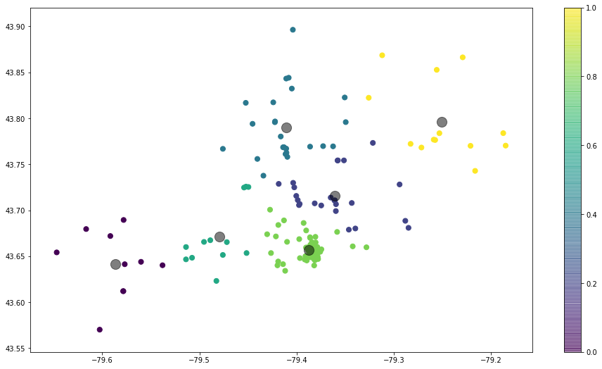

```python
# Latitude - equator=0 to poles=90 (Array 0, first value in coordinate) is represented on graph as Y axis
# Longitude - (Array 1 values, 2nd in pair ) East West, Greenwich, England, is defined as 0° longitude with west longitudes being negative. X axis on graph plot.


plt.figure(figsize=(16,9))
plt.scatter(AllStar[:, 1], AllStar[:, 0], c=y_kmeans, s=50, cmap='viridis')

centers = kmeans.cluster_centers_
plt.scatter(centers[:, 1], centers[:, 0], c='black', s=200, alpha=0.5);

plt.colorbar();  # show color scale
#plt.gca().invert_yaxis()
```

### Use K-Means Cluster Centers as new coordinates for Starbucks recommended locations search.

```python
# K-Means Cluster Centers

print(centers)
```

```
[[ 43.64147386 -79.58681121]
 [ 43.71566509 -79.3611012 ]
 [ 43.79027627 -79.4106403 ]
 [ 43.67141    -79.47982233]
 [ 43.6570237  -79.38727999]
 [ 43.79644832 -79.25056807]]
```

```python
centers.shape
```

```
(6, 2)
```

### Modified recommended search for highest ratings.

#### Change search radius from 35km to 15km; Limit from 25 to 7 and increase search coordinates to 6.

#### This keeps distance from search coordinates a major factor in results found and limits results to the few very best matches for a coordinate.

#### Increase coordinates ( Cluster Centers ) to improve coverage. Duplicates from overlapping search circles are removed.

```python
def getRecommendedK(latitudes, longitudes, radius = 15000, query = 'Starbucks', LIMIT = 7):


    recommended_all = pd.DataFrame(columns=['id', 'name', 'categories', 'address', 'lat', 'lng'])
    i = 0

    for latitude, longitude in zip(latitudes, longitudes):
        print('centroid: ', i, latitude, longitude)

        # create the API request URL

        url = 'https://api.foursquare.com/v2/search/recommendations?&client_id={}&client_secret={}&v={}&ll={},{}&radius={}&query={}&limit={}'.format(
            CLIENT_ID,
            CLIENT_SECRET,
            VERSION,
            latitude,
            longitude,
            radius,
            query,
            LIMIT)
        print(url) # display URL


        # make the GET request
        results = requests.get(url).json()
        recommended = results['response']['group']['results']
        recommended_df = pd.json_normalize(recommended) # flatten JSON

        # filter columns
        filtered_columns = ['venue.id', 'venue.name', 'venue.categories', 'venue.location.address', 'venue.location.lat', 'venue.location.lng']
        recommended_venues = recommended_df.loc[:, filtered_columns]

        # filter the category for each row
        recommended_venues['venue.categories'] = recommended_venues.apply(get_categories, axis=1)

        # clean columns
        recommended_venues.columns = [col.split(".")[-1] for col in recommended_venues.columns]
        recommended_all = pd.concat([recommended_all, recommended_venues])
        print('recommended_all size: ', recommended_all.shape)
        i = i +1

    recommended_all = recommended_all.drop_duplicates(subset='id', ignore_index=True)
    print('recommended_all size: ', recommended_all.shape)

    return(recommended_all)
```

### Recommended Starbucks from 6 search coordinates

```python
# Run the above function
# recommended_starbucks_clusters = getRecommended(latitudes=centers[:, 0], longitudes=centers[:, 1])

toronto_recommended = getRecommendedK(latitudes=centers[:, 0], longitudes=centers[:, 1])
```

```
centroid:  0 43.6414738638916 -79.58681121347733
https://api.foursquare.com/v2/search/recommendations?&client_id=1O1KN544PAGAVX5SIEEO4SINNIYJTELH1YMHPSOPLESWN1VF&client_secret=3VB4HIYI1IYA0SYA5L3TLAJM0P4KFGOZ45FRMYMSGXCR4FTV&v=20200514&ll=43.6414738638916,-79.58681121347733&radius=15000&query=Starbucks&limit=7
recommended_all size:  (7, 6)
centroid:  1 43.715665090250454 -79.36110119752628
https://api.foursquare.com/v2/search/recommendations?&client_id=1O1KN544PAGAVX5SIEEO4SINNIYJTELH1YMHPSOPLESWN1VF&client_secret=3VB4HIYI1IYA0SYA5L3TLAJM0P4KFGOZ45FRMYMSGXCR4FTV&v=20200514&ll=43.715665090250454,-79.36110119752628&radius=15000&query=Starbucks&limit=7
recommended_all size:  (14, 6)
centroid:  2 43.79027627233592 -79.41064030020135
https://api.foursquare.com/v2/search/recommendations?&client_id=1O1KN544PAGAVX5SIEEO4SINNIYJTELH1YMHPSOPLESWN1VF&client_secret=3VB4HIYI1IYA0SYA5L3TLAJM0P4KFGOZ45FRMYMSGXCR4FTV&v=20200514&ll=43.79027627233592,-79.41064030020135&radius=15000&query=Starbucks&limit=7
recommended_all size:  (21, 6)
centroid:  3 43.67141 -79.47982233333333
https://api.foursquare.com/v2/search/recommendations?&client_id=1O1KN544PAGAVX5SIEEO4SINNIYJTELH1YMHPSOPLESWN1VF&client_secret=3VB4HIYI1IYA0SYA5L3TLAJM0P4KFGOZ45FRMYMSGXCR4FTV&v=20200514&ll=43.67141,-79.47982233333333&radius=15000&query=Starbucks&limit=7
recommended_all size:  (28, 6)
centroid:  4 43.65702369951924 -79.38727999081543
https://api.foursquare.com/v2/search/recommendations?&client_id=1O1KN544PAGAVX5SIEEO4SINNIYJTELH1YMHPSOPLESWN1VF&client_secret=3VB4HIYI1IYA0SYA5L3TLAJM0P4KFGOZ45FRMYMSGXCR4FTV&v=20200514&ll=43.65702369951924,-79.38727999081543&radius=15000&query=Starbucks&limit=7
recommended_all size:  (35, 6)
centroid:  5 43.796448323201936 -79.25056806664766
https://api.foursquare.com/v2/search/recommendations?&client_id=1O1KN544PAGAVX5SIEEO4SINNIYJTELH1YMHPSOPLESWN1VF&client_secret=3VB4HIYI1IYA0SYA5L3TLAJM0P4KFGOZ45FRMYMSGXCR4FTV&v=20200514&ll=43.796448323201936,-79.25056806664766&radius=15000&query=Starbucks&limit=7
recommended_all size:  (42, 6)
recommended_all size:  (36, 6)
```

```python
#  Recommendation Map showing results of 4 regions
#  parse_html=True

latitude = 43.68
longitude = -79.39143665

map = folium.Map(location=[latitude, longitude], zoom_start=12, control_scale=True)


# I can add markers on the map with popup for Postal Code but borough name will not work reliably with variety of
# characters, such as / . ''. Use folium.Popup with parse_html



# Recommended Starbucks
for i in range(0,len(toronto_recommended)):
    folium.Marker([toronto_recommended.iloc[i]['lat'], toronto_recommended.iloc[i]['lng']],
                  popup=folium.Popup(toronto_recommended.iloc[i]['address'], parse_html=True),
                  icon=folium.Icon(color='green', icon='info-sign')
                  ).add_to(map)





# map.save('map_Recommended_Starbucks_All_Clusters_20200722.html')

map
```

[interactive chart not shown]

### Toronto's Recommended Starbucks with 6 search coordinates

```python
toronto_recommended
```

|  | id | name | categories | address | lat | lng |
| --- | --- | --- | --- | --- | --- | --- |
| 0 | 4fe0a850e4b0c602e5be4414 | Starbucks | Coffee Shop | 25 The West Mall, 1606 | 43.611693 | -79.557183 |
| 1 | 505b5b7be4b0b951796f99f7 | Starbucks | Coffee Shop | 5251 Dundas St W | 43.638135 | -79.537814 |
| 2 | 524a147b11d2985983efdcb6 | Starbucks | Coffee Shop | 1560 Dundas Street East | 43.612016 | -79.578583 |
| 3 | 52abc3b011d279cc571a9e77 | Starbucks | Coffee Shop | 3559 Lake Shore Blvd W | 43.594427 | -79.533384 |
| 4 | 5795107e498e8543b851ff51 | Starbucks | Coffee Shop | 1016 Eglinton Ave E | 43.627514 | -79.628820 |
| 5 | 5cebda3300b068002dca9d81 | Starbucks | Coffee Shop | 666 Burnhamthorpe Rd | 43.641312 | -79.576924 |
| 6 | 58b2048f2f91cb48ee2e766e | Starbucks | Coffee Shop | 1750 The Queensway, Unit 4 | 43.615206 | -79.557446 |
| 7 | 5a8743ed1543c734d2840194 | Starbucks Reserve Bar | Coffee Shop | 1090 Don Mills Rd | 43.735764 | -79.344156 |
| 8 | 4aec6b7df964a520e0c621e3 | Starbucks | Coffee Shop | 2451 Yonge St N | 43.711039 | -79.398924 |
| 9 | 4ad9c161f964a520a11a21e3 | Starbucks | Coffee Shop | 39 Eglinton Ave E | 43.706859 | -79.396950 |
| 10 | 4f61206ce4b071dd72d715fd | Starbucks | Coffee Shop | 878 Eglinton Ave E | 43.713756 | -79.365021 |
| 11 | 4ae52541f964a5206aa021e3 | Starbucks | Coffee Shop | 1088 Yonge St | 43.678020 | -79.390240 |
| 12 | 4ad8888ff964a520141221e3 | Starbucks | Coffee Shop | 485 Church St | 43.664980 | -79.380510 |
| 13 | 4b0feea1f964a5206a6623e3 | Starbucks | Coffee Shop | 900 Eglinton Ave W | 43.700598 | -79.427433 |
| 14 | 567f320d498e414f8a8a40ac | Starbucks | Coffee Shop | 6355 Yonge St | 43.796409 | -79.419653 |
| 15 | 4aedfeadf964a52005d121e3 | Starbucks | Coffee Shop | 5140 Yonge St | 43.768353 | -79.413046 |
| 16 | 4c3c7eba86ce328f2ccbab2d | Starbucks | Coffee Shop | 8010 Bathurst St, Building C, Unit 6 | 43.816777 | -79.452391 |
| 17 | 4b07279bf964a5205cf822e3 | Starbucks | Coffee Shop | 7787 Yonge Street | 43.817307 | -79.424102 |
| 18 | 5d10db203e8ac400238e1bf1 | Starbucks | Coffee Shop | 5650 Yonge St, Ste 101 | 43.780178 | -79.416408 |
| 19 | 4b05f2bef964a52064e622e3 | Starbucks | Coffee Shop | 626 Sheppard Avenue West | 43.755797 | -79.440471 |
| 20 | 544bc764498eb6708774a72f | Starbucks | Coffee Shop | 1320 Castlefield Ave, Building D | 43.699807 | -79.461804 |
| 21 | 55e30b6f498ea6ed7eff1188 | Starbucks | Coffee Shop | 1228 St. Clair Avenue West | 43.677574 | -79.445221 |
| 22 | 4af74251f964a520ba0722e3 | Starbucks | Coffee Shop | 2210 Bloor St | 43.651395 | -79.475990 |
| 23 | 4dc9d2add4c07b350108956a | Starbucks | Coffee Shop | 657 Dupont St | 43.671530 | -79.421400 |
| 24 | 576d30ed498ef2e95e26e6d0 | Starbucks | Coffee Shop | 101 College St | 43.659456 | -79.390411 |
| 25 | 4ad88b02f964a5202c1221e3 | Starbucks | Coffee Shop | 2 Bloor Street East, C3 | 43.670620 | -79.386304 |
| 26 | 4d249ace0e998cfa43b9253f | Starbucks | Coffee Shop | 50 Bloor St W, Unit C10 Holt Renfrew Centre | 43.670340 | -79.388262 |
| 27 | 4ae60299f964a52003a421e3 | Starbucks | Coffee Shop | 180 Queen St W, Suite 102.3A | 43.650751 | -79.388047 |
| 28 | 4b689994f964a52030822be3 | Starbucks | Coffee Shop | 200 Bay Street, CUR9 | 43.646799 | -79.380690 |
| 29 | 54b8669a498e7bffed909876 | Starbucks | Coffee Shop | 1156 Kennedy Rd | 43.752465 | -79.276364 |
| 30 | 4be499ba8a8cb713cd4cc4a0 | Starbucks | Coffee Shop | 201 Main Street | 43.868473 | -79.312043 |
| 31 | 4ad8bf7df964a5204c1421e3 | Starbucks | Coffee Shop | 2555 Victoria Park Avenue | 43.773219 | -79.321634 |
| 32 | 4b6c612af964a52029352ce3 | Starbucks | Coffee Shop | 20 William Kitchen Rd | 43.772163 | -79.282827 |
| 33 | 4d9b165a7668f04d3869c993 | Starbucks | Coffee Shop | 43 Milner Ave, Unit 2 | 43.783742 | -79.253186 |
| 34 | 4af5f0def964a52021ff21e3 | Starbucks | Coffee Shop | 1300 Kingston Rd | 43.836606 | -79.090204 |
| 35 | 4cc1d28c06c254815ac18547 | Starbucks | Coffee Shop | 300 Borough Dr | 43.770037 | -79.221156 |

```python
# Create a rating column
# df['My new column'] = 'default value'


toronto_recommended['rating'] = '0.0'
toronto_recommended
```

|  | id | name | categories | address | lat | lng | rating |
| --- | --- | --- | --- | --- | --- | --- | --- |
| 0 | 4fe0a850e4b0c602e5be4414 | Starbucks | Coffee Shop | 25 The West Mall, 1606 | 43.611693 | -79.557183 | 0.0 |
| 1 | 505b5b7be4b0b951796f99f7 | Starbucks | Coffee Shop | 5251 Dundas St W | 43.638135 | -79.537814 | 0.0 |
| 2 | 524a147b11d2985983efdcb6 | Starbucks | Coffee Shop | 1560 Dundas Street East | 43.612016 | -79.578583 | 0.0 |
| 3 | 52abc3b011d279cc571a9e77 | Starbucks | Coffee Shop | 3559 Lake Shore Blvd W | 43.594427 | -79.533384 | 0.0 |
| 4 | 5795107e498e8543b851ff51 | Starbucks | Coffee Shop | 1016 Eglinton Ave E | 43.627514 | -79.628820 | 0.0 |
| 5 | 5cebda3300b068002dca9d81 | Starbucks | Coffee Shop | 666 Burnhamthorpe Rd | 43.641312 | -79.576924 | 0.0 |
| 6 | 58b2048f2f91cb48ee2e766e | Starbucks | Coffee Shop | 1750 The Queensway, Unit 4 | 43.615206 | -79.557446 | 0.0 |
| 7 | 5a8743ed1543c734d2840194 | Starbucks Reserve Bar | Coffee Shop | 1090 Don Mills Rd | 43.735764 | -79.344156 | 0.0 |
| 8 | 4aec6b7df964a520e0c621e3 | Starbucks | Coffee Shop | 2451 Yonge St N | 43.711039 | -79.398924 | 0.0 |
| 9 | 4ad9c161f964a520a11a21e3 | Starbucks | Coffee Shop | 39 Eglinton Ave E | 43.706859 | -79.396950 | 0.0 |
| 10 | 4f61206ce4b071dd72d715fd | Starbucks | Coffee Shop | 878 Eglinton Ave E | 43.713756 | -79.365021 | 0.0 |
| 11 | 4ae52541f964a5206aa021e3 | Starbucks | Coffee Shop | 1088 Yonge St | 43.678020 | -79.390240 | 0.0 |
| 12 | 4ad8888ff964a520141221e3 | Starbucks | Coffee Shop | 485 Church St | 43.664980 | -79.380510 | 0.0 |
| 13 | 4b0feea1f964a5206a6623e3 | Starbucks | Coffee Shop | 900 Eglinton Ave W | 43.700598 | -79.427433 | 0.0 |
| 14 | 567f320d498e414f8a8a40ac | Starbucks | Coffee Shop | 6355 Yonge St | 43.796409 | -79.419653 | 0.0 |
| 15 | 4aedfeadf964a52005d121e3 | Starbucks | Coffee Shop | 5140 Yonge St | 43.768353 | -79.413046 | 0.0 |
| 16 | 4c3c7eba86ce328f2ccbab2d | Starbucks | Coffee Shop | 8010 Bathurst St, Building C, Unit 6 | 43.816777 | -79.452391 | 0.0 |
| 17 | 4b07279bf964a5205cf822e3 | Starbucks | Coffee Shop | 7787 Yonge Street | 43.817307 | -79.424102 | 0.0 |
| 18 | 5d10db203e8ac400238e1bf1 | Starbucks | Coffee Shop | 5650 Yonge St, Ste 101 | 43.780178 | -79.416408 | 0.0 |
| 19 | 4b05f2bef964a52064e622e3 | Starbucks | Coffee Shop | 626 Sheppard Avenue West | 43.755797 | -79.440471 | 0.0 |
| 20 | 544bc764498eb6708774a72f | Starbucks | Coffee Shop | 1320 Castlefield Ave, Building D | 43.699807 | -79.461804 | 0.0 |
| 21 | 55e30b6f498ea6ed7eff1188 | Starbucks | Coffee Shop | 1228 St. Clair Avenue West | 43.677574 | -79.445221 | 0.0 |
| 22 | 4af74251f964a520ba0722e3 | Starbucks | Coffee Shop | 2210 Bloor St | 43.651395 | -79.475990 | 0.0 |
| 23 | 4dc9d2add4c07b350108956a | Starbucks | Coffee Shop | 657 Dupont St | 43.671530 | -79.421400 | 0.0 |
| 24 | 576d30ed498ef2e95e26e6d0 | Starbucks | Coffee Shop | 101 College St | 43.659456 | -79.390411 | 0.0 |
| 25 | 4ad88b02f964a5202c1221e3 | Starbucks | Coffee Shop | 2 Bloor Street East, C3 | 43.670620 | -79.386304 | 0.0 |
| 26 | 4d249ace0e998cfa43b9253f | Starbucks | Coffee Shop | 50 Bloor St W, Unit C10 Holt Renfrew Centre | 43.670340 | -79.388262 | 0.0 |
| 27 | 4ae60299f964a52003a421e3 | Starbucks | Coffee Shop | 180 Queen St W, Suite 102.3A | 43.650751 | -79.388047 | 0.0 |
| 28 | 4b689994f964a52030822be3 | Starbucks | Coffee Shop | 200 Bay Street, CUR9 | 43.646799 | -79.380690 | 0.0 |
| 29 | 54b8669a498e7bffed909876 | Starbucks | Coffee Shop | 1156 Kennedy Rd | 43.752465 | -79.276364 | 0.0 |
| 30 | 4be499ba8a8cb713cd4cc4a0 | Starbucks | Coffee Shop | 201 Main Street | 43.868473 | -79.312043 | 0.0 |
| 31 | 4ad8bf7df964a5204c1421e3 | Starbucks | Coffee Shop | 2555 Victoria Park Avenue | 43.773219 | -79.321634 | 0.0 |
| 32 | 4b6c612af964a52029352ce3 | Starbucks | Coffee Shop | 20 William Kitchen Rd | 43.772163 | -79.282827 | 0.0 |
| 33 | 4d9b165a7668f04d3869c993 | Starbucks | Coffee Shop | 43 Milner Ave, Unit 2 | 43.783742 | -79.253186 | 0.0 |
| 34 | 4af5f0def964a52021ff21e3 | Starbucks | Coffee Shop | 1300 Kingston Rd | 43.836606 | -79.090204 | 0.0 |
| 35 | 4cc1d28c06c254815ac18547 | Starbucks | Coffee Shop | 300 Borough Dr | 43.770037 | -79.221156 | 0.0 |

```python
# Create a Pandas Series with just the id numbers for the top Starbucks

t_starbucks_id = toronto_recommended.id.iloc[:]
```

```python
len(t_starbucks_id)
```

```
36
```

```python
t_starbucks_id
```

```
0     4fe0a850e4b0c602e5be4414
1     505b5b7be4b0b951796f99f7
2     524a147b11d2985983efdcb6
3     52abc3b011d279cc571a9e77
4     5795107e498e8543b851ff51
5     5cebda3300b068002dca9d81
6     58b2048f2f91cb48ee2e766e
7     5a8743ed1543c734d2840194
8     4aec6b7df964a520e0c621e3
9     4ad9c161f964a520a11a21e3
10    4f61206ce4b071dd72d715fd
11    4ae52541f964a5206aa021e3
12    4ad8888ff964a520141221e3
13    4b0feea1f964a5206a6623e3
14    567f320d498e414f8a8a40ac
```

[output cut: 22 more lines]

```python
# Venue Details for Toronto Starbucks Top Ratings
```

### For each Starbucks id listed, get Venue Details which includes rating.

### This is a Premium endpoint. Restrictions apply based on your account type.

### The Foursquare API has a limit of 950 Regular API Calls per day and 50 Premium API Calls per day

```python
for i in range(0,len(t_starbucks_id)):
    venue_id = t_starbucks_id.iloc[i]

    url = 'https://api.foursquare.com/v2/venues/{}?&client_id={}&client_secret={}&v={}'.format(
        venue_id,
        CLIENT_ID,
        CLIENT_SECRET,
        VERSION)
    print(url) # display URL

    results = requests.get(url).json()
    My_Toronto_Rating = results['response']['venue']['rating']
    toronto_recommended.loc[i, 'rating'] = My_Toronto_Rating
    print('My_Toronto_Rating: ', My_Toronto_Rating)
```

[output not shown]

[output cut: 13 more lines]

```
My_Toronto_Rating:  8.5
https://api.foursquare.com/v2/venues/55e82dc3498e2dd663a96173?&client_id=1O1KN544PAGAVX5SIEEO4SINNIYJTELH1YMHPSOPLESWN1VF&client_secret=3VB4HIYI1IYA0SYA5L3TLAJM0P4KFGOZ45FRMYMSGXCR4FTV&v=20200514
My_Toronto_Rating:  7.5
https://api.foursquare.com/v2/venues/576d30ed498ef2e95e26e6d0?&client_id=1O1KN544PAGAVX5SIEEO4SINNIYJTELH1YMHPSOPLESWN1VF&client_secret=3VB4HIYI1IYA0SYA5L3TLAJM0P4KFGOZ45FRMYMSGXCR4FTV&v=20200514
My_Toronto_Rating:  7.6
https://api.foursquare.com/v2/venues/54272108498e36575eaba8ad?&client_id=1O1KN544PAGAVX5SIEEO4SINNIYJTELH1YMHPSOPLESWN1VF&client_secret=3VB4HIYI1IYA0SYA5L3TLAJM0P4KFGOZ45FRMYMSGXCR4FTV&v=20200514
My_Toronto_Rating:  7.8
https://api.foursquare.com/v2/venues/4ae60299f964a52003a421e3?&client_id=1O1KN544PAGAVX5SIEEO4SINNIYJTELH1YMHPSOPLESWN1VF&client_secret=3VB4HIYI1IYA0SYA5L3TLAJM0P4KFGOZ45FRMYMSGXCR4FTV&v=20200514
My_Toronto_Rating:  7.5
https://api.foursquare.com/v2/venues/4ad88b02f964a5202c1221e3?&client_id=1O1KN544PAGAVX5SIEEO4SINNIYJTELH1YMHPSOPLESWN1VF&client_secret=3VB4HIYI1IYA0SYA5L3TLAJM0P4KFGOZ45FRMYMSGXCR4FTV&v=20200514
My_Toronto_Rating:  7.7
https://api.foursquare.com/v2/venues/4d249ace0e998cfa43b9253f?&client_id=1O1KN544PAGAVX5SIEEO4SINNIYJTELH1YMHPSOPLESWN1VF&client_secret=3VB4HIYI1IYA0SYA5L3TLAJM0P4KFGOZ45FRMYMSGXCR4FTV&v=20200514
My_Toronto_Rating:  7.6
https://api.foursquare.com/v2/venues/4b689994f964a52030822be3?&client_id=1O1KN544PAGAVX5SIEEO4SINNIYJTELH1YMHPSOPLESWN1VF&client_secret=3VB4HIYI1IYA0SYA5L3TLAJM0P4KFGOZ45FRMYMSGXCR4FTV&v=20200514
My_Toronto_Rating:  7.5
```

```python
# df.sort_values(by='col1', ascending=False)

toronto_ratings_sorted = toronto_recommended.sort_values(by='rating', ascending=False)

toronto_ratings_sorted
```

|  | id | name | categories | address | lat | lng | rating |
| --- | --- | --- | --- | --- | --- | --- | --- |
| 18 | 55fd4770498e7a8fbc9082fe | Starbucks | Coffee Shop | 829 The Queensway | 43.624654 | -79.508217 | 8.9 |
| 26 | 4e85e67d9a523c072086c589 | Starbucks | Coffee Shop | 170 Rimrock Road, Unit 3 | 43.758597 | -79.466252 | 8.5 |
| 8 | 5a8743ed1543c734d2840194 | Starbucks Reserve Bar | Coffee Shop | 1090 Don Mills Rd | 43.735764 | -79.344156 | 8.5 |
| 12 | 567f320d498e414f8a8a40ac | Starbucks | Coffee Shop | 6355 Yonge St | 43.796409 | -79.419653 | 8.5 |
| 0 | 4aec6b7df964a520e0c621e3 | Starbucks | Coffee Shop | 2451 Yonge St N | 43.711039 | -79.398924 | 8.4 |
| 19 | 551486ff498ee91ac6d40f43 | Starbucks | Coffee Shop | 150 Park Lawn Rd, Unit A | 43.627931 | -79.489286 | 8.4 |
| 21 | 4fe0a850e4b0c602e5be4414 | Starbucks | Coffee Shop | 25 The West Mall, 1606 | 43.611693 | -79.557183 | 8.2 |
| 11 | 4be499ba8a8cb713cd4cc4a0 | Starbucks | Coffee Shop | 201 Main Street | 43.868473 | -79.312043 | 8.1 |
| 23 | 52abc3b011d279cc571a9e77 | Starbucks | Coffee Shop | 3559 Lake Shore Blvd W | 43.594427 | -79.533384 | 8.1 |
| 4 | 4ad8888ff964a520141221e3 | Starbucks | Coffee Shop | 485 Church St | 43.664980 | -79.380510 | 8.1 |
| 1 | 4ad9c161f964a520a11a21e3 | Starbucks | Coffee Shop | 39 Eglinton Ave E | 43.706859 | -79.396950 | 8 |
| 17 | 4c3c7eba86ce328f2ccbab2d | Starbucks | Coffee Shop | 8010 Bathurst St, Building C, Unit 6 | 43.816777 | -79.452391 | 8 |
| 20 | 505b5b7be4b0b951796f99f7 | Starbucks | Coffee Shop | 5251 Dundas St W | 43.638135 | -79.537814 | 7.9 |
| 25 | 4aedfeadf964a52005d121e3 | Starbucks | Coffee Shop | 5140 Yonge St | 43.768353 | -79.413046 | 7.9 |
| 2 | 4ae52541f964a5206aa021e3 | Starbucks | Coffee Shop | 1088 Yonge St | 43.678020 | -79.390240 | 7.9 |
| 3 | 4b0feea1f964a5206a6623e3 | Starbucks | Coffee Shop | 900 Eglinton Ave W | 43.700598 | -79.427433 | 7.8 |
| 15 | 4b07279bf964a5205cf822e3 | Starbucks | Coffee Shop | 7787 Yonge Street | 43.817307 | -79.424102 | 7.8 |
| 7 | 54b8669a498e7bffed909876 | Starbucks | Coffee Shop | 1156 Kennedy Rd | 43.752465 | -79.276364 | 7.8 |
| 29 | 54272108498e36575eaba8ad | Starbucks | Coffee Shop | 600 Fleet St, 18 | 43.636679 | -79.400321 | 7.8 |
| 22 | 5244b19111d24c95f862af2b | Starbucks | Coffee Shop | 374 Evans Avenue | 43.616190 | -79.525714 | 7.8 |
| 31 | 4ad88b02f964a5202c1221e3 | Starbucks | Coffee Shop | 2 Bloor Street East, C3 | 43.670620 | -79.386304 | 7.7 |
| 32 | 4d249ace0e998cfa43b9253f | Starbucks | Coffee Shop | 50 Bloor St W, Unit C10 Holt Renfrew Centre | 43.670340 | -79.388262 | 7.6 |
| 9 | 4ad8bf7df964a5204c1421e3 | Starbucks | Coffee Shop | 2555 Victoria Park Avenue | 43.773219 | -79.321634 | 7.6 |
| 13 | 4b05a292f964a520fedf22e3 | Starbucks | Coffee Shop | 2880 Major Mackenzie, 3 | 43.885178 | -79.372822 | 7.6 |
| 28 | 576d30ed498ef2e95e26e6d0 | Starbucks | Coffee Shop | 101 College St | 43.659456 | -79.390411 | 7.6 |
| 27 | 55e82dc3498e2dd663a96173 | Starbucks | Coffee Shop | 4025 Yonge St | 43.744871 | -79.406289 | 7.5 |
| 30 | 4ae60299f964a52003a421e3 | Starbucks | Coffee Shop | 180 Queen St W, Suite 102.3A | 43.650751 | -79.388047 | 7.5 |
| 33 | 4b689994f964a52030822be3 | Starbucks | Coffee Shop | 200 Bay Street, CUR9 | 43.646799 | -79.380690 | 7.5 |
| 5 | 4aec6bbaf964a520e6c621e3 | Starbucks | Coffee Shop | 2630 Yonge St | 43.715590 | -79.400450 | 7.5 |
| 14 | 4b32a302f964a520991025e3 | Starbucks | Coffee Shop | 8750 Bayview Ave, Unit 1 | 43.844060 | -79.408230 | 7.5 |
| 24 | 4b87eb6ff964a520e8d231e3 | Starbucks | Coffee Shop | 3079-3081 Bloor St W | 43.646597 | -79.513914 | 7.4 |
| 6 | 4f79e8a1e4b03b459fae7e97 | Starbucks | Coffee Shop | 694 Mount Pleasant | 43.705923 | -79.389548 | 7.4 |
| 16 | 5aaeba4e5a2c912c129564a5 | Starbucks | Coffee Shop | 3000 Highway 7 East, A14 | 43.850581 | -79.357732 | 7.2 |
| 10 | 4b6c612af964a52029352ce3 | Starbucks | Coffee Shop | 20 William Kitchen Rd | 43.772163 | -79.282827 | 6.9 |

#### Save a copy of ratings df to local file.

```python
# df.to_pickle('file_name')  # where to save it, usually as a .pkl

toronto_ratings_sorted.to_pickle('Toronto_Starbucks_Top34_ratings_20200712.pkl')
```

```python
toronto_ratings_sorted = pd.read_pickle('Toronto_Starbucks_Top34_ratings_20200712.pkl')
toronto_ratings_sorted
```

|  | id | name | categories | address | lat | lng | rating |
| --- | --- | --- | --- | --- | --- | --- | --- |
| 18 | 55fd4770498e7a8fbc9082fe | Starbucks | Coffee Shop | 829 The Queensway | 43.624654 | -79.508217 | 8.9 |
| 26 | 4e85e67d9a523c072086c589 | Starbucks | Coffee Shop | 170 Rimrock Road, Unit 3 | 43.758597 | -79.466252 | 8.5 |
| 8 | 5a8743ed1543c734d2840194 | Starbucks Reserve Bar | Coffee Shop | 1090 Don Mills Rd | 43.735764 | -79.344156 | 8.5 |
| 12 | 567f320d498e414f8a8a40ac | Starbucks | Coffee Shop | 6355 Yonge St | 43.796409 | -79.419653 | 8.5 |
| 0 | 4aec6b7df964a520e0c621e3 | Starbucks | Coffee Shop | 2451 Yonge St N | 43.711039 | -79.398924 | 8.4 |
| 19 | 551486ff498ee91ac6d40f43 | Starbucks | Coffee Shop | 150 Park Lawn Rd, Unit A | 43.627931 | -79.489286 | 8.4 |
| 21 | 4fe0a850e4b0c602e5be4414 | Starbucks | Coffee Shop | 25 The West Mall, 1606 | 43.611693 | -79.557183 | 8.2 |
| 11 | 4be499ba8a8cb713cd4cc4a0 | Starbucks | Coffee Shop | 201 Main Street | 43.868473 | -79.312043 | 8.1 |
| 23 | 52abc3b011d279cc571a9e77 | Starbucks | Coffee Shop | 3559 Lake Shore Blvd W | 43.594427 | -79.533384 | 8.1 |
| 4 | 4ad8888ff964a520141221e3 | Starbucks | Coffee Shop | 485 Church St | 43.664980 | -79.380510 | 8.1 |
| 1 | 4ad9c161f964a520a11a21e3 | Starbucks | Coffee Shop | 39 Eglinton Ave E | 43.706859 | -79.396950 | 8 |
| 17 | 4c3c7eba86ce328f2ccbab2d | Starbucks | Coffee Shop | 8010 Bathurst St, Building C, Unit 6 | 43.816777 | -79.452391 | 8 |
| 20 | 505b5b7be4b0b951796f99f7 | Starbucks | Coffee Shop | 5251 Dundas St W | 43.638135 | -79.537814 | 7.9 |
| 25 | 4aedfeadf964a52005d121e3 | Starbucks | Coffee Shop | 5140 Yonge St | 43.768353 | -79.413046 | 7.9 |
| 2 | 4ae52541f964a5206aa021e3 | Starbucks | Coffee Shop | 1088 Yonge St | 43.678020 | -79.390240 | 7.9 |
| 3 | 4b0feea1f964a5206a6623e3 | Starbucks | Coffee Shop | 900 Eglinton Ave W | 43.700598 | -79.427433 | 7.8 |
| 15 | 4b07279bf964a5205cf822e3 | Starbucks | Coffee Shop | 7787 Yonge Street | 43.817307 | -79.424102 | 7.8 |
| 7 | 54b8669a498e7bffed909876 | Starbucks | Coffee Shop | 1156 Kennedy Rd | 43.752465 | -79.276364 | 7.8 |
| 29 | 54272108498e36575eaba8ad | Starbucks | Coffee Shop | 600 Fleet St, 18 | 43.636679 | -79.400321 | 7.8 |
| 22 | 5244b19111d24c95f862af2b | Starbucks | Coffee Shop | 374 Evans Avenue | 43.616190 | -79.525714 | 7.8 |
| 31 | 4ad88b02f964a5202c1221e3 | Starbucks | Coffee Shop | 2 Bloor Street East, C3 | 43.670620 | -79.386304 | 7.7 |
| 32 | 4d249ace0e998cfa43b9253f | Starbucks | Coffee Shop | 50 Bloor St W, Unit C10 Holt Renfrew Centre | 43.670340 | -79.388262 | 7.6 |
| 9 | 4ad8bf7df964a5204c1421e3 | Starbucks | Coffee Shop | 2555 Victoria Park Avenue | 43.773219 | -79.321634 | 7.6 |
| 13 | 4b05a292f964a520fedf22e3 | Starbucks | Coffee Shop | 2880 Major Mackenzie, 3 | 43.885178 | -79.372822 | 7.6 |
| 28 | 576d30ed498ef2e95e26e6d0 | Starbucks | Coffee Shop | 101 College St | 43.659456 | -79.390411 | 7.6 |
| 27 | 55e82dc3498e2dd663a96173 | Starbucks | Coffee Shop | 4025 Yonge St | 43.744871 | -79.406289 | 7.5 |
| 30 | 4ae60299f964a52003a421e3 | Starbucks | Coffee Shop | 180 Queen St W, Suite 102.3A | 43.650751 | -79.388047 | 7.5 |
| 33 | 4b689994f964a52030822be3 | Starbucks | Coffee Shop | 200 Bay Street, CUR9 | 43.646799 | -79.380690 | 7.5 |
| 5 | 4aec6bbaf964a520e6c621e3 | Starbucks | Coffee Shop | 2630 Yonge St | 43.715590 | -79.400450 | 7.5 |
| 14 | 4b32a302f964a520991025e3 | Starbucks | Coffee Shop | 8750 Bayview Ave, Unit 1 | 43.844060 | -79.408230 | 7.5 |
| 24 | 4b87eb6ff964a520e8d231e3 | Starbucks | Coffee Shop | 3079-3081 Bloor St W | 43.646597 | -79.513914 | 7.4 |
| 6 | 4f79e8a1e4b03b459fae7e97 | Starbucks | Coffee Shop | 694 Mount Pleasant | 43.705923 | -79.389548 | 7.4 |
| 16 | 5aaeba4e5a2c912c129564a5 | Starbucks | Coffee Shop | 3000 Highway 7 East, A14 | 43.850581 | -79.357732 | 7.2 |
| 10 | 4b6c612af964a52029352ce3 | Starbucks | Coffee Shop | 20 William Kitchen Rd | 43.772163 | -79.282827 | 6.9 |

```python
toronto_ratings_sorted.iloc[0:15]
```

|  | id | name | categories | address | lat | lng | rating |
| --- | --- | --- | --- | --- | --- | --- | --- |
| 18 | 55fd4770498e7a8fbc9082fe | Starbucks | Coffee Shop | 829 The Queensway | 43.624654 | -79.508217 | 8.9 |
| 26 | 4e85e67d9a523c072086c589 | Starbucks | Coffee Shop | 170 Rimrock Road, Unit 3 | 43.758597 | -79.466252 | 8.5 |
| 8 | 5a8743ed1543c734d2840194 | Starbucks Reserve Bar | Coffee Shop | 1090 Don Mills Rd | 43.735764 | -79.344156 | 8.5 |
| 12 | 567f320d498e414f8a8a40ac | Starbucks | Coffee Shop | 6355 Yonge St | 43.796409 | -79.419653 | 8.5 |
| 0 | 4aec6b7df964a520e0c621e3 | Starbucks | Coffee Shop | 2451 Yonge St N | 43.711039 | -79.398924 | 8.4 |
| 19 | 551486ff498ee91ac6d40f43 | Starbucks | Coffee Shop | 150 Park Lawn Rd, Unit A | 43.627931 | -79.489286 | 8.4 |
| 21 | 4fe0a850e4b0c602e5be4414 | Starbucks | Coffee Shop | 25 The West Mall, 1606 | 43.611693 | -79.557183 | 8.2 |
| 11 | 4be499ba8a8cb713cd4cc4a0 | Starbucks | Coffee Shop | 201 Main Street | 43.868473 | -79.312043 | 8.1 |
| 23 | 52abc3b011d279cc571a9e77 | Starbucks | Coffee Shop | 3559 Lake Shore Blvd W | 43.594427 | -79.533384 | 8.1 |
| 4 | 4ad8888ff964a520141221e3 | Starbucks | Coffee Shop | 485 Church St | 43.664980 | -79.380510 | 8.1 |
| 1 | 4ad9c161f964a520a11a21e3 | Starbucks | Coffee Shop | 39 Eglinton Ave E | 43.706859 | -79.396950 | 8 |
| 17 | 4c3c7eba86ce328f2ccbab2d | Starbucks | Coffee Shop | 8010 Bathurst St, Building C, Unit 6 | 43.816777 | -79.452391 | 8 |
| 20 | 505b5b7be4b0b951796f99f7 | Starbucks | Coffee Shop | 5251 Dundas St W | 43.638135 | -79.537814 | 7.9 |
| 25 | 4aedfeadf964a52005d121e3 | Starbucks | Coffee Shop | 5140 Yonge St | 43.768353 | -79.413046 | 7.9 |
| 2 | 4ae52541f964a5206aa021e3 | Starbucks | Coffee Shop | 1088 Yonge St | 43.678020 | -79.390240 | 7.9 |

```python
toronto_top12 = toronto_ratings_sorted.iloc[0:12]
```

```python
toronto_top12.rating.mean()
```

```
8.308333333333332
```

```python
# toronto_recommended & toronto_top12
```

```python
#  Recommendation Map showing results of 4 regions
#  parse_html=True

latitude = 43.68
longitude = -79.39143665

map = folium.Map(location=[latitude, longitude], zoom_start=12, control_scale=True)


# I can add markers on the map with popup for Postal Code but borough name will not work reliably with variety of
# characters, such as / . ''. Use folium.Popup with parse_html



# Recommended Starbucks
for i in range(0,len(toronto_recommended)):
    folium.Marker([toronto_recommended.iloc[i]['lat'], toronto_recommended.iloc[i]['lng']],
                  popup=folium.Popup(toronto_recommended.iloc[i]['address'], parse_html=True),
                  icon=folium.Icon(color='green', icon='info-sign')
                  ).add_to(map)


# Recommended Starbucks
for i in range(0,len(toronto_top12)):
    folium.Marker([toronto_top12.iloc[i]['lat'], toronto_top12.iloc[i]['lng']],
                  popup=folium.Popup(toronto_top12.iloc[i]['address'], parse_html=True),
                  icon=folium.Icon(color='purple', icon='info-sign')
                  ).add_to(map)


# map.save('map_Recommended_Starbucks_All_Clusters_20200722.html')

map
```

[interactive chart not shown]

```python
# The high concentration of Starbucks downtown and through North York made the St Louis method ineffective at
# seeing the highly rated store at the east & west edges of the metropolitan area.

# K-Means Clustering of All Starbucks and then using a smaller search radius with 6 search coordinates was better input
# to Venue Details for Ratings.
```

### getRecommendedIntent function call

```python
### Recommended Intent Coffee
```

```python
centers = np.array([[ 43.7033298,  -79.39925157],
         [ 43.75347165, -79.26539844],
         [ 43.85302029, -79.36836471],
         [ 43.63831453, -79.51188786],
         [ 43.77103916, -79.40794771],
         [ 43.65442317, -79.38426413]])
```

```python
# recommended_starbucks_clusters = getRecommendedIntent(intent, latitudes=centers[:, 0], longitudes=centers[:, 1])

intent = 'coffee'
recommended_coffee_t = getRecommendedIntent(intent, latitudes=centers[:, 0], longitudes=centers[:, 1])
```

```
centroid:  0 43.7033298 -79.39925157
https://api.foursquare.com/v2/search/recommendations?&client_id=1O1KN544PAGAVX5SIEEO4SINNIYJTELH1YMHPSOPLESWN1VF&client_secret=3VB4HIYI1IYA0SYA5L3TLAJM0P4KFGOZ45FRMYMSGXCR4FTV&v=20200514&ll=43.7033298,-79.39925157&radius=15000&intent=coffee&limit=50
recommended_all size:  (50, 6)
centroid:  1 43.75347165 -79.26539844
https://api.foursquare.com/v2/search/recommendations?&client_id=1O1KN544PAGAVX5SIEEO4SINNIYJTELH1YMHPSOPLESWN1VF&client_secret=3VB4HIYI1IYA0SYA5L3TLAJM0P4KFGOZ45FRMYMSGXCR4FTV&v=20200514&ll=43.75347165,-79.26539844&radius=15000&intent=coffee&limit=50
recommended_all size:  (100, 6)
centroid:  2 43.85302029 -79.36836471
https://api.foursquare.com/v2/search/recommendations?&client_id=1O1KN544PAGAVX5SIEEO4SINNIYJTELH1YMHPSOPLESWN1VF&client_secret=3VB4HIYI1IYA0SYA5L3TLAJM0P4KFGOZ45FRMYMSGXCR4FTV&v=20200514&ll=43.85302029,-79.36836471&radius=15000&intent=coffee&limit=50
recommended_all size:  (150, 6)
centroid:  3 43.63831453 -79.51188786
https://api.foursquare.com/v2/search/recommendations?&client_id=1O1KN544PAGAVX5SIEEO4SINNIYJTELH1YMHPSOPLESWN1VF&client_secret=3VB4HIYI1IYA0SYA5L3TLAJM0P4KFGOZ45FRMYMSGXCR4FTV&v=20200514&ll=43.63831453,-79.51188786&radius=15000&intent=coffee&limit=50
recommended_all size:  (200, 6)
centroid:  4 43.77103916 -79.40794771
https://api.foursquare.com/v2/search/recommendations?&client_id=1O1KN544PAGAVX5SIEEO4SINNIYJTELH1YMHPSOPLESWN1VF&client_secret=3VB4HIYI1IYA0SYA5L3TLAJM0P4KFGOZ45FRMYMSGXCR4FTV&v=20200514&ll=43.77103916,-79.40794771&radius=15000&intent=coffee&limit=50
recommended_all size:  (250, 6)
centroid:  5 43.65442317 -79.38426413
https://api.foursquare.com/v2/search/recommendations?&client_id=1O1KN544PAGAVX5SIEEO4SINNIYJTELH1YMHPSOPLESWN1VF&client_secret=3VB4HIYI1IYA0SYA5L3TLAJM0P4KFGOZ45FRMYMSGXCR4FTV&v=20200514&ll=43.65442317,-79.38426413&radius=15000&intent=coffee&limit=50
recommended_all size:  (300, 6)
recommended_all size:  (172, 6)
```

```python
recommended_coffee_t.head(20)
```

|  | id | name | categories | address | lat | lng |
| --- | --- | --- | --- | --- | --- | --- |
| 0 | 544d3b30498e333e2fa24c53 | Istanbul Cafe & Espresso Bar | Café | 174 Eglinton Avenue East | 43.707891 | -79.393049 |
| 1 | 51819802498ee3c6834b8e0b | De Mello Palheta Coffee Roasters | Coffee Shop | 2489 Yonge St | 43.711791 | -79.399403 |
| 2 | 4aea4fd3f964a520f6ba21e3 | DAVIDsTEA | Tea Room | 2389 Yonge St | 43.709870 | -79.398757 |
| 3 | 4f4d31aee4b0ef284ae397ea | Himalayan Java | Café | 2552 Yonge St | 43.713486 | -79.399811 |
| 4 | 4b939ca4f964a520344a34e3 | Thobors Boulangerie Patisserie Café | Café | 627 Mt Pleasant Rd. | 43.704514 | -79.388616 |
| 5 | 5282572111d2f33612220715 | Boxcar Social | Coffee Shop | 1208 Yonge St. | 43.681750 | -79.391447 |
| 6 | 4ad9c161f964a520a11a21e3 | Starbucks | Coffee Shop | 39 Eglinton Ave E | 43.706859 | -79.396950 |
| 7 | 502bb730e4b01590f997803d | Aroma Espresso Bar | Café | 2040 Avenue Rd. | 43.735975 | -79.420391 |
| 8 | 4b6f0c25f964a52060d92ce3 | CocoaLatte | Café | 671 St. Clair Ave. W. | 43.681768 | -79.425158 |
| 9 | 569e7814498e1a7f3e01bfe4 | Rooster Coffee House | Coffee Shop | 568 Jarvis St | 43.669654 | -79.379871 |
| 10 | 4b5c7ad5f964a520df3129e3 | Tre Mari Bakery | Café | 1307 St. Clair Ave West | 43.676487 | -79.448650 |
| 11 | 5061dbab498ee603149683e5 | Voodoo Child | Café | 388 College street | 43.656958 | -79.405460 |
| 12 | 540c8301498e51456f71ae7e | Contra Cafe | Café | 1028 Shaw St | 43.669107 | -79.426105 |
| 13 | 4b4626fef964a5204a1826e3 | Rooster Coffee House | Café | 479 Broadview Ave | 43.669177 | -79.353134 |
| 14 | 57d8114f498ef2e8301f9348 | The Good Neighbour | Coffee Shop | 678 Bloor St W | 43.663983 | -79.416640 |
| 15 | 5a81ae339deb7d369fa7f146 | Hailed Coffee | Coffee Shop | 44 Gerrard St W | 43.658833 | -79.383684 |
| 16 | 56d4d1b3cd1035fe77e1492c | Page One Cafe | Café | 106 Mutual St | 43.657772 | -79.376073 |
| 17 | 5a3aa18a5455b26eb31333d2 | Filosophy | Café | 912 Bloor Street | 43.661879 | -79.426471 |
| 18 | 502652fee4b0e6861eab1f29 | Merchants of Green Coffee | Coffee Shop | 2 Matilda St | 43.659916 | -79.353963 |
| 19 | 572e0547498ed619e59df508 | Hale Coffee | Coffee Shop | 300 Campbell St | 43.665532 | -79.449949 |

```python
# df[df['A'].str.contains("hello")]

recommended_coffee_t[recommended_coffee_t['name'].str.contains("Starbucks")]
```

|  | id | name | categories | address | lat | lng |
| --- | --- | --- | --- | --- | --- | --- |
| 6 | 4ad9c161f964a520a11a21e3 | Starbucks | Coffee Shop | 39 Eglinton Ave E | 43.706859 | -79.396950 |
| 40 | 4ae52541f964a5206aa021e3 | Starbucks | Coffee Shop | 1088 Yonge St | 43.678020 | -79.390240 |
| 44 | 5a8743ed1543c734d2840194 | Starbucks Reserve Bar | Coffee Shop | 1090 Don Mills Rd | 43.735764 | -79.344156 |
| 50 | 54b8669a498e7bffed909876 | Starbucks | Coffee Shop | 1156 Kennedy Rd | 43.752465 | -79.276364 |
| 71 | 4b6c612af964a52029352ce3 | Starbucks | Coffee Shop | 20 William Kitchen Rd | 43.772163 | -79.282827 |
| 78 | 4b05a292f964a520fedf22e3 | Starbucks | Coffee Shop | 2880 Major Mackenzie, 3 | 43.885178 | -79.372822 |
| 80 | 4b32a302f964a520991025e3 | Starbucks | Coffee Shop | 8750 Bayview Ave, Unit 1 | 43.844060 | -79.408230 |
| 81 | 5aaeba4e5a2c912c129564a5 | Starbucks | Coffee Shop | 3000 Highway 7 East, A14 | 43.850581 | -79.357732 |
| 119 | 55fd4770498e7a8fbc9082fe | Starbucks | Coffee Shop | 829 The Queensway | 43.624654 | -79.508217 |
| 120 | 551486ff498ee91ac6d40f43 | Starbucks | Coffee Shop | 150 Park Lawn Rd, Unit A | 43.627931 | -79.489286 |
| 134 | 52abc3b011d279cc571a9e77 | Starbucks | Coffee Shop | 3559 Lake Shore Blvd W | 43.594427 | -79.533384 |
| 138 | 4b87eb6ff964a520e8d231e3 | Starbucks | Coffee Shop | 3079-3081 Bloor St W | 43.646597 | -79.513914 |
| 150 | 54490365498e78a9fe510022 | Starbucks | Coffee Shop | 10 Lower Spadina Ave | 43.637735 | -79.392203 |
| 151 | 567f320d498e414f8a8a40ac | Starbucks | Coffee Shop | 6355 Yonge St | 43.796409 | -79.419653 |
| 152 | 4aedfeadf964a52005d121e3 | Starbucks | Coffee Shop | 5140 Yonge St | 43.768353 | -79.413046 |
| 154 | 5d10db203e8ac400238e1bf1 | Starbucks | Coffee Shop | 5650 Yonge St, Ste 101 | 43.780178 | -79.416408 |
| 164 | 4b6b4340f964a520c9fc2be3 | Starbucks | Coffee Shop | 55 University Ave, Unit #3 | 43.646731 | -79.383951 |

```python
# How many Starbucks made the Recommended List?
# 16

len(recommended_coffee_t[recommended_coffee_t['name'].str.contains("Starbucks")])
```

```
17
```

```python
# 172 Recommended Coffee Venues in Toronto / 16 Starbucks = 9%

toronto_recommended_starbucks = len(recommended_coffee_t[recommended_coffee_t['name'].str.contains("Starbucks")]) / len(recommended_coffee_t)
```

```python
StL_recommended_starbucks = len(recommended_coffee_StL[recommended_coffee_StL['name'].str.contains("Starbucks")]) / len(recommended_coffee_StL)
```

```python
# Who's the Best?
```

### Which City gets the Highest Average Rating for its Top 12 Starbucks Locations?

```python
starbucks_Top_12_ratings.rating.mean()
#StLouis_Starbucks_Top_12.rating.mean()
```

```
8.499999999999998
```

```python
toronto_top12.rating.mean()
```

```
8.308333333333332
```

### Which City has more stores on the Recommended list for all coffee venues?

```python
print('Percentage of Starbucks in St. Louis on the Recommended list: ', StL_recommended_starbucks * 100)
```

```
Percentage of Starbucks in St. Louis on the Recommended list:  14.37908496732026
```

```python
print('Percentage of Starbucks in Toronto on the Recommended list: ', toronto_recommended_starbucks * 100)
```

```
Percentage of Starbucks in Toronto on the Recommended list:  9.883720930232558
```

### St Louis Starbucks Wins with 14 % of their locations on the recommended list of all coffee venues !

### And, St. Louis wins for having a top store average rating of 8.5 !

Table_of_Contents